# Supervised Learning : Resampling Procedures for Model Hyperparameter Tuning and Internal Validation

John Pauline Pineda

November 24, 2022

# **1. Table of Contents**

This project explores different resampling procedures during model hyperparameter tuning and internal validation using various helpful packages in **R**. Using a **Recursive Partitioning and Regression Trees** model structure, resampling methods applied in the analysis for tuning model hyperparameters and internally validating model performance included **K-Fold Cross Validation**, **Repeated K-Fold Cross Validation**, **Leave-One-Out Cross Validation**, **Leave-Group-Out Cross Validation**, **Bootstrap Validation**, **Bootstrap 0.632 Validation** and **Bootstrap with Optimism-Estimation Validation**. The resulting predictions derived from the candidate models with their respective optimal hyperparameters were evaluated in terms of their classification performance using the accuracy metric, which were subsequently compared to the baseline model’s apparent performance values.  
Data resampling consists of various techniques for estimating the generalizability of a model using only the data available during model development, which typically involves partitioning from the available data to simulate potential variability in the wider population. This process is essential for optimizing model hyperparemeters and internally validating a predictive model’s performance with respect to optimism or overfitting. Overfitting refers to the condition when a statistical model intended to make general predictions about a population instead narrowly describes the unique variations present only in the sample dataset used to train it. One common cause for overfitting is using a sample dataset that’s insufficiently representative of the population it was drawn from. Hyperparameter tuning is the process of determining the optimal combination of hyperparameter values that maximizes the model performance by running multiple trials in a single training process. Hyperparameters refer to external configuration variables that are used to control the learning process and have a significant effect on the performance of machine learning models but are fixed and cannot be directly learned from the regular training process. The resampling procedures applied in this study (mostly contained in the **caret** package) attempt to train the models sequentially by searching for the optimal hyperparameters and internally estimating the model performance for unseen data.

## 1.1 Sample Data

The **GermanCredit** dataset from the **caret** package was used for this illustrated example.  
Preliminary dataset assessment:  
**[A]** 1000 rows (observations)  
**[B]** 62 columns (variables)  
**[B.1]** 1/62 response = Class variable (factor)  
**[B.1.1]** 2 levels = Bad versus Good  
**[B.2]** 61/62 predictors = All remaining variables (54/61 factor + 7/61 numeric)

**Code Chunk | Output**

```r
##################################
# Loading R libraries
##################################
library(AppliedPredictiveModeling)
library(caret)
library(rpart)
library(lattice)
library(dplyr)
library(moments)
library(skimr)
library(RANN)
library(corrplot)
library(tidyverse)
library(lares)
library(DMwR)
library(gridExtra)
library(rattle)
library(rpart.plot)
library(RColorBrewer)

##################################
# Loading dataset
##################################
data(GermanCredit)

##################################
# Performing a general exploration of the dataset
##################################
dim(GermanCredit)
```

```
## [1] 1000   62
```

```r
str(GermanCredit)
```

```
## 'data.frame':    1000 obs. of  62 variables:
##  $ Duration                              : int  6 48 12 42 24 36 24 36 12 30 ...
##  $ Amount                                : int  1169 5951 2096 7882 4870 9055 2835 6948 3059 5234 ...
##  $ InstallmentRatePercentage             : int  4 2 2 2 3 2 3 2 2 4 ...
##  $ ResidenceDuration                     : int  4 2 3 4 4 4 4 2 4 2 ...
##  $ Age                                   : int  67 22 49 45 53 35 53 35 61 28 ...
##  $ NumberExistingCredits                 : int  2 1 1 1 2 1 1 1 1 2 ...
##  $ NumberPeopleMaintenance               : int  1 1 2 2 2 2 1 1 1 1 ...
##  $ Telephone                             : num  0 1 1 1 1 0 1 0 1 1 ...
##  $ ForeignWorker                         : num  1 1 1 1 1 1 1 1 1 1 ...
##  $ Class                                 : Factor w/ 2 levels "Bad","Good": 2 1 2 2 1 2 2 2 2 1 ...
##  $ CheckingAccountStatus.lt.0            : num  1 0 0 1 1 0 0 0 0 0 ...
##  $ CheckingAccountStatus.0.to.200        : num  0 1 0 0 0 0 0 1 0 1 ...
##  $ CheckingAccountStatus.gt.200          : num  0 0 0 0 0 0 0 0 0 0 ...
##  $ CheckingAccountStatus.none            : num  0 0 1 0 0 1 1 0 1 0 ...
```

[output cut: 48 more lines]

```r
summary(GermanCredit)
```

```
##     Duration        Amount      InstallmentRatePercentage ResidenceDuration
##  Min.   : 4.0   Min.   :  250   Min.   :1.000             Min.   :1.000
##  1st Qu.:12.0   1st Qu.: 1366   1st Qu.:2.000             1st Qu.:2.000
##  Median :18.0   Median : 2320   Median :3.000             Median :3.000
##  Mean   :20.9   Mean   : 3271   Mean   :2.973             Mean   :2.845
##  3rd Qu.:24.0   3rd Qu.: 3972   3rd Qu.:4.000             3rd Qu.:4.000
##  Max.   :72.0   Max.   :18424   Max.   :4.000             Max.   :4.000
##       Age        NumberExistingCredits NumberPeopleMaintenance   Telephone
##  Min.   :19.00   Min.   :1.000         Min.   :1.000           Min.   :0.000
##  1st Qu.:27.00   1st Qu.:1.000         1st Qu.:1.000           1st Qu.:0.000
##  Median :33.00   Median :1.000         Median :1.000           Median :1.000
##  Mean   :35.55   Mean   :1.407         Mean   :1.155           Mean   :0.596
##  3rd Qu.:42.00   3rd Qu.:2.000         3rd Qu.:1.000           3rd Qu.:1.000
##  Max.   :75.00   Max.   :4.000         Max.   :2.000           Max.   :1.000
##  ForeignWorker    Class     CheckingAccountStatus.lt.0
##  Min.   :0.000   Bad :300   Min.   :0.000
##  1st Qu.:1.000   Good:700   1st Qu.:0.000
##  Median :1.000              Median :0.000
##  Mean   :0.963              Mean   :0.274
##  3rd Qu.:1.000              3rd Qu.:1.000
##  Max.   :1.000              Max.   :1.000
##  CheckingAccountStatus.0.to.200 CheckingAccountStatus.gt.200
##  Min.   :0.000                  Min.   :0.000
##  1st Qu.:0.000                  1st Qu.:0.000
##  Median :0.000                  Median :0.000
##  Mean   :0.269                  Mean   :0.063
##  3rd Qu.:1.000                  3rd Qu.:0.000
##  Max.   :1.000                  Max.   :1.000
##  CheckingAccountStatus.none CreditHistory.NoCredit.AllPaid
##  Min.   :0.000              Min.   :0.00
##  1st Qu.:0.000              1st Qu.:0.00
##  Median :0.000              Median :0.00
##  Mean   :0.394              Mean   :0.04
##  3rd Qu.:1.000              3rd Qu.:0.00
##  Max.   :1.000              Max.   :1.00
##  CreditHistory.ThisBank.AllPaid CreditHistory.PaidDuly CreditHistory.Delay
##  Min.   :0.000                  Min.   :0.00           Min.   :0.000
##  1st Qu.:0.000                  1st Qu.:0.00           1st Qu.:0.000
##  Median :0.000                  Median :1.00           Median :0.000
##  Mean   :0.049                  Mean   :0.53           Mean   :0.088
```

[output cut: 99 more lines]

```
##  Max.   :1.000                Max.   :1.000              Max.   :1.000
##   Housing.Own    Housing.ForFree Job.UnemployedUnskilled Job.UnskilledResident
##  Min.   :0.000   Min.   :0.000   Min.   :0.000           Min.   :0.0
##  1st Qu.:0.000   1st Qu.:0.000   1st Qu.:0.000           1st Qu.:0.0
##  Median :1.000   Median :0.000   Median :0.000           Median :0.0
##  Mean   :0.713   Mean   :0.108   Mean   :0.022           Mean   :0.2
##  3rd Qu.:1.000   3rd Qu.:0.000   3rd Qu.:0.000           3rd Qu.:0.0
##  Max.   :1.000   Max.   :1.000   Max.   :1.000           Max.   :1.0
##  Job.SkilledEmployee Job.Management.SelfEmp.HighlyQualified
##  Min.   :0.00        Min.   :0.000
##  1st Qu.:0.00        1st Qu.:0.000
##  Median :1.00        Median :0.000
##  Mean   :0.63        Mean   :0.148
##  3rd Qu.:1.00        3rd Qu.:0.000
##  Max.   :1.00        Max.   :1.000
```

```r
##################################
# Formulating a data type assessment summary
##################################
PDA <- GermanCredit
(PDA.Summary <- data.frame(
  Column.Index=c(1:length(names(PDA))),
  Column.Name= names(PDA),
  Column.Type=sapply(PDA, function(x) class(x)),
  row.names=NULL)
)
```

```
##    Column.Index                            Column.Name Column.Type
## 1             1                               Duration     integer
## 2             2                                 Amount     integer
## 3             3              InstallmentRatePercentage     integer
## 4             4                      ResidenceDuration     integer
## 5             5                                    Age     integer
## 6             6                  NumberExistingCredits     integer
## 7             7                NumberPeopleMaintenance     integer
## 8             8                              Telephone     numeric
## 9             9                          ForeignWorker     numeric
## 10           10                                  Class      factor
## 11           11             CheckingAccountStatus.lt.0     numeric
## 12           12         CheckingAccountStatus.0.to.200     numeric
## 13           13           CheckingAccountStatus.gt.200     numeric
## 14           14             CheckingAccountStatus.none     numeric
```

[output cut: 48 more lines]

## 1.2 Data Quality Assessment

Data quality assessment:  
**[A]** No missing observations noted for any variable.  
**[B]** Low variance observed for 30 variables with First.Second.Mode.Ratio>5.  
**[B.1]** ForeignWorker variable (factor)  
**[B.2]** CheckingAccountStatus.gt.200 variable (factor)  
**[B.3]** CreditHistory.NoCredit.AllPaid variable (factor)  
**[B.4]** CreditHistory.ThisBank.AllPaid variable (factor)  
**[B.5]** CreditHistory.Delay variable (factor)  
**[B.6]** Purpose.UsedCar variable (factor)  
**[B.7]** Purpose.DomesticAppliance variable (factor)  
**[B.8]** Purpose.Repairs variable (factor)  
**[B.9]** Purpose.Education variable (factor)  
**[B.10]** Purpose.Vacation variable (factor)  
**[B.11]** Purpose.Retraining variable (factor)  
**[B.12]** Purpose.Business variable (factor)  
**[B.13]** Purpose.Other variable (factor)  
**[B.14]** SavingsAccountBonds.100.to.500 variable (factor)  
**[B.15]** SavingsAccountBonds.500.to.1000 variable (factor)  
**[B.16]** SavingsAccountBonds.gt.1000 variable (factor)  
**[B.17]** EmploymentDuration.Unemployed variable (factor)  
**[B.18]** Personal.Male.Divorced.Seperated variable (factor)  
**[B.19]** Personal.Male.Married.Widowed variable (factor)  
**[B.20]** Personal.Female.Single variable (factor)  
**[B.21]** OtherDebtorsGuarantors.None variable (factor)  
**[B.22]** OtherDebtorsGuarantors.CoApplicant variable (factor)  
**[B.23]** OtherDebtorsGuarantors.Guarantor variable (factor)  
**[B.24]** Property.Unknown variable (factor)  
**[B.25]** OtherInstallmentPlans.Bank variable (factor)  
**[B.26]** OtherInstallmentPlans.Stores variable (factor)  
**[B.27]** Housing.ForFree variable (factor)  
**[B.28]** Job.UnemployedUnskilled variable (factor)  
**[B.29]** Job.Management.SelfEmp.HighlyQualified variable (factor)  
**[B.30]** NumberPeopleMaintenance variable (numeric)  
**[C]** Low variance observed for 4 variables with Unique.Count.Ratio<0.01.  
**[C.1]** InstallmentRatePercentage variable (numeric)  
**[C.2]** ResidenceDuration variable (numeric)  
**[C.3]** NumberExistingCredits variable (numeric)  
**[C.4]** NumberPeopleMaintenance variable (numeric)  
**[D]** No high skewness observed for any variable (with Skewness>3 or Skewness<(-3)).

**Code Chunk | Output**

```r
##################################
# Loading dataset
##################################
DQA <- GermanCredit

##################################
# Formulating an overall data quality assessment summary
##################################
(DQA.Summary <- data.frame(
  Column.Index=c(1:length(names(DQA))),
  Column.Name= names(DQA),
  Column.Type=sapply(DQA, function(x) class(x)),
  Row.Count=sapply(DQA, function(x) nrow(DQA)),
  NA.Count=sapply(DQA,function(x)sum(is.na(x))),
  Fill.Rate=sapply(DQA,function(x)format(round((sum(!is.na(x))/nrow(DQA)),3),nsmall=3)),
  row.names=NULL)
)
```

```
##    Column.Index                            Column.Name Column.Type Row.Count
## 1             1                               Duration     integer      1000
## 2             2                                 Amount     integer      1000
## 3             3              InstallmentRatePercentage     integer      1000
## 4             4                      ResidenceDuration     integer      1000
## 5             5                                    Age     integer      1000
## 6             6                  NumberExistingCredits     integer      1000
## 7             7                NumberPeopleMaintenance     integer      1000
## 8             8                              Telephone     numeric      1000
## 9             9                          ForeignWorker     numeric      1000
## 10           10                                  Class      factor      1000
## 11           11             CheckingAccountStatus.lt.0     numeric      1000
## 12           12         CheckingAccountStatus.0.to.200     numeric      1000
## 13           13           CheckingAccountStatus.gt.200     numeric      1000
## 14           14             CheckingAccountStatus.none     numeric      1000
```

[output cut: 111 more lines]

```r
##################################
# Listing all predictors
##################################
DQA.Predictors <- DQA[,!names(DQA) %in% c("Class")]

##################################
# Identifying and converting numeric predictors
# which should have been factor predictors
##################################

DQA.Predictors.Numeric <- DQA.Predictors[,sapply(DQA.Predictors, is.numeric)]

DQA.Predictors.Numeric.Max <- c()

for (i in 1:ncol(DQA.Predictors.Numeric)){
  DQA.Predictors.Numeric.Max.i <- max(DQA.Predictors.Numeric[,i])
  DQA.Predictors.Numeric.Max <- append(DQA.Predictors.Numeric.Max,DQA.Predictors.Numeric.Max.i)
}

DQA.Predictors.Numeric.Max.Summary <- as.data.frame(cbind(names(DQA.Predictors.Numeric),DQA.Predictors.Numeric.Max))
names(DQA.Predictors.Numeric.Max.Summary) <- c("Numeric.Predictors","Max")
DQA.Predictors.Numeric.Max.Summary$Max <- as.numeric(as.character(DQA.Predictors.Numeric.Max.Summary$Max))

DQA.Predictors.Numeric.To.Factor <- DQA.Predictors.Numeric.Max.Summary[DQA.Predictors.Numeric.Max.Summary$Max<2,]
DQA.Predictors.Numeric.To.Factor.Names <- as.vector(DQA.Predictors.Numeric.To.Factor$Numeric.Predictors)

DQA.Predictors[DQA.Predictors.Numeric.To.Factor.Names]<-lapply(DQA.Predictors[DQA.Predictors.Numeric.To.Factor.Names],factor)

##################################
# Listing all numeric predictors
##################################
DQA.Predictors.Numeric <- DQA.Predictors[,sapply(DQA.Predictors, is.numeric)]

if (length(names(DQA.Predictors.Numeric))>0) {
    print(paste0("There are ",
               (length(names(DQA.Predictors.Numeric))),
               " numeric predictor variable(s)."))
} else {
  print("There are no numeric predictor variables.")
}
```

```
## [1] "There are 7 numeric predictor variable(s)."
```

```r
##################################
# Listing all factor predictors
##################################
DQA.Predictors.Factor <- DQA.Predictors[,sapply(DQA.Predictors, is.factor)]

if (length(names(DQA.Predictors.Factor))>0) {
    print(paste0("There are ",
               (length(names(DQA.Predictors.Factor))),
               " factor predictor variable(s)."))
} else {
  print("There are no factor predictor variables.")
}
```

```
## [1] "There are 54 factor predictor variable(s)."
```

```r
##################################
# Formulating a data quality assessment summary for factor predictors
##################################
if (length(names(DQA.Predictors.Factor))>0) {

  ##################################
  # Formulating a function to determine the first mode
  ##################################
  FirstModes <- function(x) {
    ux <- unique(na.omit(x))
    tab <- tabulate(match(x, ux))
    ux[tab == max(tab)]
  }

  ##################################
  # Formulating a function to determine the second mode
  ##################################
  SecondModes <- function(x) {
    ux <- unique(na.omit(x))
    tab <- tabulate(match(x, ux))
    fm = ux[tab == max(tab)]
    sm = x[!(x %in% fm)]
    usm <- unique(sm)
    tabsm <- tabulate(match(sm, usm))
    ifelse(is.na(usm[tabsm == max(tabsm)])==TRUE,
           return("x"),
           return(usm[tabsm == max(tabsm)]))
  }

  (DQA.Predictors.Factor.Summary <- data.frame(
  Column.Name= names(DQA.Predictors.Factor),
  Column.Type=sapply(DQA.Predictors.Factor, function(x) class(x)),
  Unique.Count=sapply(DQA.Predictors.Factor, function(x) length(unique(x))),
  First.Mode.Value=sapply(DQA.Predictors.Factor, function(x) as.character(FirstModes(x)[1])),
  Second.Mode.Value=sapply(DQA.Predictors.Factor, function(x) as.character(SecondModes(x)[1])),
  First.Mode.Count=sapply(DQA.Predictors.Factor, function(x) sum(na.omit(x) == FirstModes(x)[1])),
  Second.Mode.Count=sapply(DQA.Predictors.Factor, function(x) sum(na.omit(x) == SecondModes(x)[1])),
  Unique.Count.Ratio=sapply(DQA.Predictors.Factor, function(x) format(round((length(unique(x))/nrow(DQA.Predictors.Factor)),3), nsmall=3)),
  First.Second.Mode.Ratio=sapply(DQA.Predictors.Factor, function(x) format(round((sum(na.omit(x) == FirstModes(x)[1])/sum(na.omit(x) == SecondModes(x)[1])),3), nsmall=3)),
  row.names=NULL)
  )

}
```

```
##                               Column.Name Column.Type Unique.Count
## 1                               Telephone      factor            2
## 2                           ForeignWorker      factor            2
## 3              CheckingAccountStatus.lt.0      factor            2
## 4          CheckingAccountStatus.0.to.200      factor            2
## 5            CheckingAccountStatus.gt.200      factor            2
## 6              CheckingAccountStatus.none      factor            2
## 7          CreditHistory.NoCredit.AllPaid      factor            2
## 8          CreditHistory.ThisBank.AllPaid      factor            2
## 9                  CreditHistory.PaidDuly      factor            2
## 10                    CreditHistory.Delay      factor            2
## 11                 CreditHistory.Critical      factor            2
## 12                         Purpose.NewCar      factor            2
## 13                        Purpose.UsedCar      factor            2
## 14            Purpose.Furniture.Equipment      factor            2
```

[output cut: 150 more lines]

```r
##################################
# Formulating a data quality assessment summary for numeric predictors
##################################
if (length(names(DQA.Predictors.Numeric))>0) {

  ##################################
  # Formulating a function to determine the first mode
  ##################################
  FirstModes <- function(x) {
    ux <- unique(na.omit(x))
    tab <- tabulate(match(x, ux))
    ux[tab == max(tab)]
  }

  ##################################
  # Formulating a function to determine the second mode
  ##################################
  SecondModes <- function(x) {
    ux <- unique(na.omit(x))
    tab <- tabulate(match(x, ux))
    fm = ux[tab == max(tab)]
    sm = na.omit(x)[!(na.omit(x) %in% fm)]
    usm <- unique(sm)
    tabsm <- tabulate(match(sm, usm))
    ifelse(is.na(usm[tabsm == max(tabsm)])==TRUE,
           return(0.00001),
           return(usm[tabsm == max(tabsm)]))
  }

  (DQA.Predictors.Numeric.Summary <- data.frame(
  Column.Name= names(DQA.Predictors.Numeric),
  Column.Type=sapply(DQA.Predictors.Numeric, function(x) class(x)),
  Unique.Count=sapply(DQA.Predictors.Numeric, function(x) length(unique(x))),
  Unique.Count.Ratio=sapply(DQA.Predictors.Numeric, function(x) format(round((length(unique(x))/nrow(DQA.Predictors.Numeric)),3), nsmall=3)),
  First.Mode.Value=sapply(DQA.Predictors.Numeric, function(x) format(round((FirstModes(x)[1]),3),nsmall=3)),
  Second.Mode.Value=sapply(DQA.Predictors.Numeric, function(x) format(round((SecondModes(x)[1]),3),nsmall=3)),
  First.Mode.Count=sapply(DQA.Predictors.Numeric, function(x) sum(na.omit(x) == FirstModes(x)[1])),
  Second.Mode.Count=sapply(DQA.Predictors.Numeric, function(x) sum(na.omit(x) == SecondModes(x)[1])),
  First.Second.Mode.Ratio=sapply(DQA.Predictors.Numeric, function(x) format(round((sum(na.omit(x) == FirstModes(x)[1])/sum(na.omit(x) == SecondModes(x)[1])),3), nsmall=3)),
  Minimum=sapply(DQA.Predictors.Numeric, function(x) format(round(min(x,na.rm = TRUE),3), nsmall=3)),
  Mean=sapply(DQA.Predictors.Numeric, function(x) format(round(mean(x,na.rm = TRUE),3), nsmall=3)),
  Median=sapply(DQA.Predictors.Numeric, function(x) format(round(median(x,na.rm = TRUE),3), nsmall=3)),
  Maximum=sapply(DQA.Predictors.Numeric, function(x) format(round(max(x,na.rm = TRUE),3), nsmall=3)),
  Skewness=sapply(DQA.Predictors.Numeric, function(x) format(round(skewness(x,na.rm = TRUE),3), nsmall=3)),
  Kurtosis=sapply(DQA.Predictors.Numeric, function(x) format(round(kurtosis(x,na.rm = TRUE),3), nsmall=3)),
  Percentile25th=sapply(DQA.Predictors.Numeric, function(x) format(round(quantile(x,probs=0.25,na.rm = TRUE),3), nsmall=3)),
  Percentile75th=sapply(DQA.Predictors.Numeric, function(x) format(round(quantile(x,probs=0.75,na.rm = TRUE),3), nsmall=3)),
  row.names=NULL)
  )

}
```

```
##                 Column.Name Column.Type Unique.Count Unique.Count.Ratio
## 1                  Duration     integer           33              0.033
## 2                    Amount     integer          921              0.921
## 3 InstallmentRatePercentage     integer            4              0.004
## 4         ResidenceDuration     integer            4              0.004
## 5                       Age     integer           53              0.053
## 6     NumberExistingCredits     integer            4              0.004
## 7   NumberPeopleMaintenance     integer            2              0.002
##   First.Mode.Value Second.Mode.Value First.Mode.Count Second.Mode.Count
## 1           24.000            12.000              184               179
## 2         1393.000          1169.000                3                 2
## 3            4.000             2.000              476               231
## 4            4.000             2.000              413               308
## 5           27.000            26.000               51                50
## 6            1.000             2.000              633               333
```

[output cut: 17 more lines]

```r
##################################
# Identifying potential data quality issues
##################################

##################################
# Checking for missing observations
##################################
if ((nrow(DQA.Summary[DQA.Summary$NA.Count>0,]))>0){
  print(paste0("Missing observations noted for ",
               (nrow(DQA.Summary[DQA.Summary$NA.Count>0,])),
               " variable(s) with NA.Count>0 and Fill.Rate<1.0."))
  DQA.Summary[DQA.Summary$NA.Count>0,]
} else {
  print("No missing observations noted.")
}
```

```
## [1] "No missing observations noted."
```

```r
##################################
# Checking for zero or near-zero variance predictors
##################################
if (length(names(DQA.Predictors.Factor))==0) {
  print("No factor predictors noted.")
} else if (nrow(DQA.Predictors.Factor.Summary[as.numeric(as.character(DQA.Predictors.Factor.Summary$First.Second.Mode.Ratio))>5,])>0){
  print(paste0("Low variance observed for ",
               (nrow(DQA.Predictors.Factor.Summary[as.numeric(as.character(DQA.Predictors.Factor.Summary$First.Second.Mode.Ratio))>5,])),
               " factor variable(s) with First.Second.Mode.Ratio>5."))
  DQA.Predictors.Factor.Summary[as.numeric(as.character(DQA.Predictors.Factor.Summary$First.Second.Mode.Ratio))>5,]
} else {
  print("No low variance factor predictors due to high first-second mode ratio noted.")
}
```

```
## [1] "Low variance observed for 29 factor variable(s) with First.Second.Mode.Ratio>5."
```

```
##                               Column.Name Column.Type Unique.Count
## 2                           ForeignWorker      factor            2
## 5            CheckingAccountStatus.gt.200      factor            2
## 7          CreditHistory.NoCredit.AllPaid      factor            2
## 8          CreditHistory.ThisBank.AllPaid      factor            2
## 10                    CreditHistory.Delay      factor            2
## 13                        Purpose.UsedCar      factor            2
## 16              Purpose.DomesticAppliance      factor            2
## 17                        Purpose.Repairs      factor            2
## 18                      Purpose.Education      factor            2
## 19                       Purpose.Vacation      factor            1
## 20                     Purpose.Retraining      factor            2
## 21                       Purpose.Business      factor            2
## 22                          Purpose.Other      factor            2
## 24         SavingsAccountBonds.100.to.500      factor            2
```

[output cut: 75 more lines]

```r
if (length(names(DQA.Predictors.Numeric))==0) {
  print("No numeric predictors noted.")
} else if (nrow(DQA.Predictors.Numeric.Summary[as.numeric(as.character(DQA.Predictors.Numeric.Summary$First.Second.Mode.Ratio))>5,])>0){
  print(paste0("Low variance observed for ",
               (nrow(DQA.Predictors.Numeric.Summary[as.numeric(as.character(DQA.Predictors.Numeric.Summary$First.Second.Mode.Ratio))>5,])),
               " numeric variable(s) with First.Second.Mode.Ratio>5."))
  DQA.Predictors.Numeric.Summary[as.numeric(as.character(DQA.Predictors.Numeric.Summary$First.Second.Mode.Ratio))>5,]
} else {
  print("No low variance numeric predictors due to high first-second mode ratio noted.")
}
```

```
## [1] "Low variance observed for 1 numeric variable(s) with First.Second.Mode.Ratio>5."
```

```
##               Column.Name Column.Type Unique.Count Unique.Count.Ratio
## 7 NumberPeopleMaintenance     integer            2              0.002
##   First.Mode.Value Second.Mode.Value First.Mode.Count Second.Mode.Count
## 7            1.000             2.000              845               155
##   First.Second.Mode.Ratio Minimum  Mean Median Maximum Skewness Kurtosis
## 7                   5.452   1.000 1.155  1.000   2.000    1.907    4.635
##   Percentile25th Percentile75th
## 7          1.000          1.000
```

```r
if (length(names(DQA.Predictors.Numeric))==0) {
  print("No numeric predictors noted.")
} else if (nrow(DQA.Predictors.Numeric.Summary[as.numeric(as.character(DQA.Predictors.Numeric.Summary$Unique.Count.Ratio))<0.01,])>0){
  print(paste0("Low variance observed for ",
               (nrow(DQA.Predictors.Numeric.Summary[as.numeric(as.character(DQA.Predictors.Numeric.Summary$Unique.Count.Ratio))<0.01,])),
               " numeric variable(s) with Unique.Count.Ratio<0.01."))
  DQA.Predictors.Numeric.Summary[as.numeric(as.character(DQA.Predictors.Numeric.Summary$Unique.Count.Ratio))<0.01,]
} else {
  print("No low variance numeric predictors due to low unique count ratio noted.")
}
```

```
## [1] "Low variance observed for 4 numeric variable(s) with Unique.Count.Ratio<0.01."
```

```
##                 Column.Name Column.Type Unique.Count Unique.Count.Ratio
## 3 InstallmentRatePercentage     integer            4              0.004
## 4         ResidenceDuration     integer            4              0.004
## 6     NumberExistingCredits     integer            4              0.004
## 7   NumberPeopleMaintenance     integer            2              0.002
##   First.Mode.Value Second.Mode.Value First.Mode.Count Second.Mode.Count
## 3            4.000             2.000              476               231
## 4            4.000             2.000              413               308
## 6            1.000             2.000              633               333
## 7            1.000             2.000              845               155
##   First.Second.Mode.Ratio Minimum  Mean Median Maximum Skewness Kurtosis
## 3                   2.061   1.000 2.973  3.000   4.000   -0.531    1.790
## 4                   1.341   1.000 2.845  3.000   4.000   -0.272    1.619
## 6                   1.901   1.000 1.407  1.000   4.000    1.271    4.590
## 7                   5.452   1.000 1.155  1.000   2.000    1.907    4.635
##   Percentile25th Percentile75th
## 3          2.000          4.000
## 4          2.000          4.000
## 6          1.000          2.000
## 7          1.000          1.000
```

```r
##################################
# Checking for skewed predictors
##################################
if (length(names(DQA.Predictors.Numeric))==0) {
  print("No numeric predictors noted.")
} else if (nrow(DQA.Predictors.Numeric.Summary[as.numeric(as.character(DQA.Predictors.Numeric.Summary$Skewness))>3 |
                                               as.numeric(as.character(DQA.Predictors.Numeric.Summary$Skewness))<(-3),])>0){
  print(paste0("High skewness observed for ",
  (nrow(DQA.Predictors.Numeric.Summary[as.numeric(as.character(DQA.Predictors.Numeric.Summary$Skewness))>3 |
                                               as.numeric(as.character(DQA.Predictors.Numeric.Summary$Skewness))<(-3),])),
  " numeric variable(s) with Skewness>3 or Skewness<(-3)."))
  DQA.Predictors.Numeric.Summary[as.numeric(as.character(DQA.Predictors.Numeric.Summary$Skewness))>3 |
                                 as.numeric(as.character(DQA.Predictors.Numeric.Summary$Skewness))<(-3),]
} else {
  print("No skewed numeric predictors noted.")
}
```

```
## [1] "No skewed numeric predictors noted."
```

## 1.3 Data Preprocessing

### 1.3.1 Outlier

Outlier data assessment:  
**[A]** Outliers noted for 5 variables with the numeric data visualized through a boxplot including observations classified as suspected outliers using the IQR criterion. The IQR criterion means that all observations above the (75th percentile + 1.5 x IQR) or below the (25th percentile - 1.5 x IQR) are suspected outliers, where IQR is the difference between the third quartile (75th percentile) and first quartile (25th percentile). Outlier treatment for numerical stability remains optional depending on potential model requirements for the subsequent steps.  
**[A.1]** Duration variable (70 outliers detected)  
**[A.2]** Amount variable (72 outliers detected)  
**[A.3]** Age variable (23 outliers detected)  
**[A.4]** NumberExistingCredits variable (6 outliers detected)  
**[A.5]** NumberPeopleMaintenance variable (155 outliers detected)

**Code Chunk | Output**

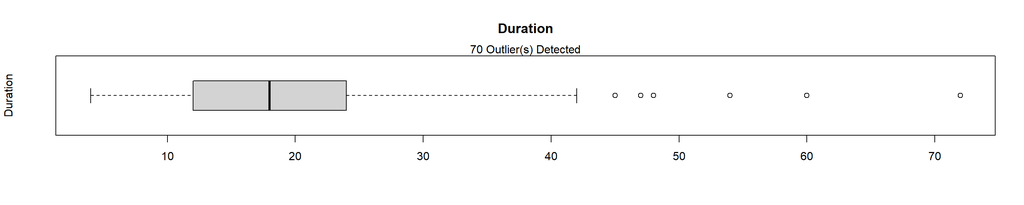

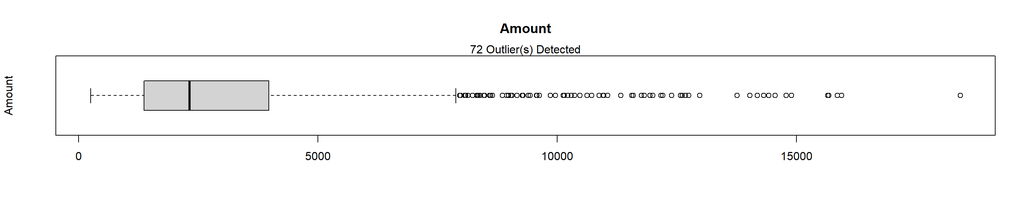

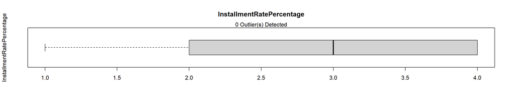

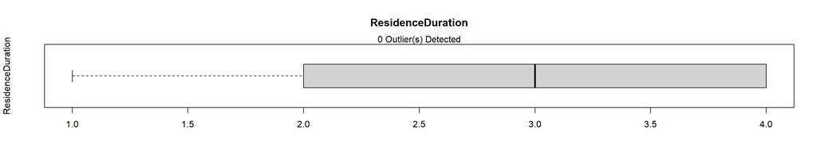

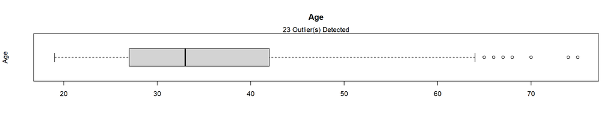

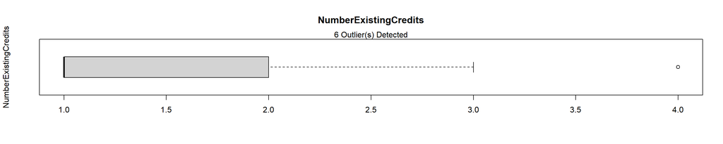

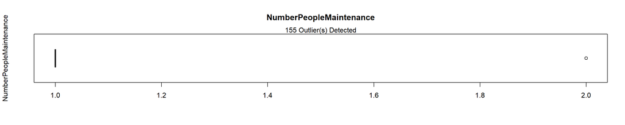

```r
##################################
# Loading dataset
##################################
DPA <- GermanCredit

##################################
# Listing all predictors
##################################
DPA.Predictors <- DQA.Predictors

##################################
# Listing all numeric predictors
##################################
DPA.Predictors.Numeric <- DQA.Predictors.Numeric

##################################
# Identifying outliers for the numeric predictors
##################################
OutlierCountList <- c()

for (i in 1:ncol(DPA.Predictors.Numeric)) {
  Outliers <- boxplot.stats(DPA.Predictors.Numeric[,i])$out
  OutlierCount <- length(Outliers)
  OutlierCountList <- append(OutlierCountList,OutlierCount)
  OutlierIndices <- which(DPA.Predictors.Numeric[,i] %in% c(Outliers))
  boxplot(DPA.Predictors.Numeric[,i],
          ylab = names(DPA.Predictors.Numeric)[i],
          main = names(DPA.Predictors.Numeric)[i],
          horizontal=TRUE)
  mtext(paste0(OutlierCount, " Outlier(s) Detected"))
}
```

```r
OutlierCountSummary <- as.data.frame(cbind(names(DPA.Predictors.Numeric),(OutlierCountList)))
names(OutlierCountSummary) <- c("NumericPredictors","OutlierCount")
OutlierCountSummary$OutlierCount <- as.numeric(as.character(OutlierCountSummary$OutlierCount))
NumericPredictorWithOutlierCount <- nrow(OutlierCountSummary[OutlierCountSummary$OutlierCount>0,])
print(paste0(NumericPredictorWithOutlierCount, " numeric variable(s) were noted with outlier(s)." ))
```

```
## [1] "5 numeric variable(s) were noted with outlier(s)."
```

```r
##################################
# Gathering descriptive statistics
##################################
(DPA_Skimmed <- skim(DPA.Predictors.Numeric))
```

Data summary

| Name | DPA.Predictors.Numeric |
| --- | --- |
| Number of rows | 1000 |
| Number of columns | 7 |
| _______________________ |  |
| Column type frequency: |  |
| numeric | 7 |
| ________________________ |  |
| Group variables | None |

**Variable type: numeric**

| skim_variable | n_missing | complete_rate | mean | sd | p0 | p25 | p50 | p75 | p100 | hist |
| --- | --- | --- | --- | --- | --- | --- | --- | --- | --- | --- |
| Duration | 0 | 1 | 20.90 | 12.06 | 4 | 12.0 | 18.0 | 24.00 | 72 | ▇▇▂▁▁ |
| Amount | 0 | 1 | 3271.26 | 2822.74 | 250 | 1365.5 | 2319.5 | 3972.25 | 18424 | ▇▂▁▁▁ |
| InstallmentRatePercentage | 0 | 1 | 2.97 | 1.12 | 1 | 2.0 | 3.0 | 4.00 | 4 | ▂▃▁▂▇ |
| ResidenceDuration | 0 | 1 | 2.85 | 1.10 | 1 | 2.0 | 3.0 | 4.00 | 4 | ▂▆▁▃▇ |
| Age | 0 | 1 | 35.55 | 11.38 | 19 | 27.0 | 33.0 | 42.00 | 75 | ▇▆▃▁▁ |
| NumberExistingCredits | 0 | 1 | 1.41 | 0.58 | 1 | 1.0 | 1.0 | 2.00 | 4 | ▇▅▁▁▁ |
| NumberPeopleMaintenance | 0 | 1 | 1.16 | 0.36 | 1 | 1.0 | 1.0 | 1.00 | 2 | ▇▁▁▁▂ |

### 1.3.2 Zero and Near-Zero Variance

Zero and near-zero variance data assessment:  
**[A]** Low variance noted for 34 variables from the previous data quality assessment using a lower threshold.  
**[B]** Low variance noted for 13 variables using a preprocessing summary from the **caret** package. The nearZeroVar method using both the freqCut and uniqueCut criteria set at 95/5 and 10, respectively, were applied on the dataset.  
**[B.1]** ForeignWorker variable (factor)  
**[B.2]** CreditHistory.NoCredit.AllPaid variable (factor)  
**[B.3]** CreditHistory.ThisBank.AllPaid variable (factor)  
**[B.4]** Purpose.DomesticAppliance variable (factor)  
**[B.5]** Purpose.Repairs variable (factor)  
**[B.6]** Purpose.Vacation variable (factor)  
**[B.7]** Purpose.Retraining variable (factor)  
**[B.8]** Purpose.Other variable (factor)  
**[B.9]** SavingsAccountBonds.gt.1000 variable (factor)  
**[B.10]** Personal.Female.Single variable (factor)  
**[B.11]** OtherDebtorsGuarantors.CoApplicant variable (factor)  
**[B.12]** OtherInstallmentPlans.Stores variable (factor)  
**[B.13]** Job.UnemployedUnskilled variable (factor)

**Code Chunk | Output**

```r
##################################
# Reusing dataset
##################################
##################################
# Identifying and converting numeric variables
# which should have been factor variables
##################################
DQA.Numeric <- DQA[,sapply(DQA, is.numeric)]

DQA.Numeric.Max <- c()

for (i in 1:ncol(DQA.Numeric)){
  DQA.Numeric.Max.i <- max(DQA.Numeric[,i])
  DQA.Numeric.Max <- append(DQA.Numeric.Max,DQA.Numeric.Max.i)
}

DQA.Numeric.Max.Summary <- as.data.frame(cbind(names(DQA.Numeric),DQA.Numeric.Max))
names(DQA.Numeric.Max.Summary) <- c("Numeric.Predictors","Max")
DQA.Numeric.Max.Summary$Max <- as.numeric(as.character(DQA.Numeric.Max.Summary$Max))

DQA.Numeric.To.Factor <- DQA.Numeric.Max.Summary[DQA.Numeric.Max.Summary$Max<2,]
DQA.Numeric.To.Factor.Names <- as.vector(DQA.Numeric.To.Factor$Numeric.Predictors)

DQA[DQA.Numeric.To.Factor.Names]<-lapply(DQA[DQA.Numeric.To.Factor.Names],factor)

DPA <- DQA

# Gathering descriptive statistics
##################################
(DPA_Skimmed <- skim(DQA))
```

Data summary

| Name | DQA |
| --- | --- |
| Number of rows | 1000 |
| Number of columns | 62 |
| _______________________ |  |
| Column type frequency: |  |
| factor | 55 |
| numeric | 7 |
| ________________________ |  |
| Group variables | None |

**Variable type: factor**

| skim_variable | n_missing | complete_rate | ordered | n_unique | top_counts |
| --- | --- | --- | --- | --- | --- |
| Telephone | 0 | 1 | FALSE | 2 | 1: 596, 0: 404 |
| ForeignWorker | 0 | 1 | FALSE | 2 | 1: 963, 0: 37 |
| Class | 0 | 1 | FALSE | 2 | Goo: 700, Bad: 300 |
| CheckingAccountStatus.lt.0 | 0 | 1 | FALSE | 2 | 0: 726, 1: 274 |
| CheckingAccountStatus.0.to.200 | 0 | 1 | FALSE | 2 | 0: 731, 1: 269 |
| CheckingAccountStatus.gt.200 | 0 | 1 | FALSE | 2 | 0: 937, 1: 63 |
| CheckingAccountStatus.none | 0 | 1 | FALSE | 2 | 0: 606, 1: 394 |
| CreditHistory.NoCredit.AllPaid | 0 | 1 | FALSE | 2 | 0: 960, 1: 40 |
| CreditHistory.ThisBank.AllPaid | 0 | 1 | FALSE | 2 | 0: 951, 1: 49 |
| CreditHistory.PaidDuly | 0 | 1 | FALSE | 2 | 1: 530, 0: 470 |
| CreditHistory.Delay | 0 | 1 | FALSE | 2 | 0: 912, 1: 88 |
| CreditHistory.Critical | 0 | 1 | FALSE | 2 | 0: 707, 1: 293 |
| Purpose.NewCar | 0 | 1 | FALSE | 2 | 0: 766, 1: 234 |
| Purpose.UsedCar | 0 | 1 | FALSE | 2 | 0: 897, 1: 103 |
| Purpose.Furniture.Equipment | 0 | 1 | FALSE | 2 | 0: 819, 1: 181 |
| Purpose.Radio.Television | 0 | 1 | FALSE | 2 | 0: 720, 1: 280 |
| Purpose.DomesticAppliance | 0 | 1 | FALSE | 2 | 0: 988, 1: 12 |
| Purpose.Repairs | 0 | 1 | FALSE | 2 | 0: 978, 1: 22 |
| Purpose.Education | 0 | 1 | FALSE | 2 | 0: 950, 1: 50 |
| Purpose.Vacation | 0 | 1 | FALSE | 1 | 0: 1000 |
| Purpose.Retraining | 0 | 1 | FALSE | 2 | 0: 991, 1: 9 |
| Purpose.Business | 0 | 1 | FALSE | 2 | 0: 903, 1: 97 |
| Purpose.Other | 0 | 1 | FALSE | 2 | 0: 988, 1: 12 |
| SavingsAccountBonds.lt.100 | 0 | 1 | FALSE | 2 | 1: 603, 0: 397 |
| SavingsAccountBonds.100.to.500 | 0 | 1 | FALSE | 2 | 0: 897, 1: 103 |
| SavingsAccountBonds.500.to.1000 | 0 | 1 | FALSE | 2 | 0: 937, 1: 63 |
| SavingsAccountBonds.gt.1000 | 0 | 1 | FALSE | 2 | 0: 952, 1: 48 |
| SavingsAccountBonds.Unknown | 0 | 1 | FALSE | 2 | 0: 817, 1: 183 |
| EmploymentDuration.lt.1 | 0 | 1 | FALSE | 2 | 0: 828, 1: 172 |
| EmploymentDuration.1.to.4 | 0 | 1 | FALSE | 2 | 0: 661, 1: 339 |
| EmploymentDuration.4.to.7 | 0 | 1 | FALSE | 2 | 0: 826, 1: 174 |
| EmploymentDuration.gt.7 | 0 | 1 | FALSE | 2 | 0: 747, 1: 253 |
| EmploymentDuration.Unemployed | 0 | 1 | FALSE | 2 | 0: 938, 1: 62 |
| Personal.Male.Divorced.Seperated | 0 | 1 | FALSE | 2 | 0: 950, 1: 50 |
| Personal.Female.NotSingle | 0 | 1 | FALSE | 2 | 0: 690, 1: 310 |
| Personal.Male.Single | 0 | 1 | FALSE | 2 | 1: 548, 0: 452 |
| Personal.Male.Married.Widowed | 0 | 1 | FALSE | 2 | 0: 908, 1: 92 |
| Personal.Female.Single | 0 | 1 | FALSE | 1 | 0: 1000 |
| OtherDebtorsGuarantors.None | 0 | 1 | FALSE | 2 | 1: 907, 0: 93 |
| OtherDebtorsGuarantors.CoApplicant | 0 | 1 | FALSE | 2 | 0: 959, 1: 41 |
| OtherDebtorsGuarantors.Guarantor | 0 | 1 | FALSE | 2 | 0: 948, 1: 52 |
| Property.RealEstate | 0 | 1 | FALSE | 2 | 0: 718, 1: 282 |
| Property.Insurance | 0 | 1 | FALSE | 2 | 0: 768, 1: 232 |
| Property.CarOther | 0 | 1 | FALSE | 2 | 0: 668, 1: 332 |
| Property.Unknown | 0 | 1 | FALSE | 2 | 0: 846, 1: 154 |
| OtherInstallmentPlans.Bank | 0 | 1 | FALSE | 2 | 0: 861, 1: 139 |
| OtherInstallmentPlans.Stores | 0 | 1 | FALSE | 2 | 0: 953, 1: 47 |
| OtherInstallmentPlans.None | 0 | 1 | FALSE | 2 | 1: 814, 0: 186 |
| Housing.Rent | 0 | 1 | FALSE | 2 | 0: 821, 1: 179 |
| Housing.Own | 0 | 1 | FALSE | 2 | 1: 713, 0: 287 |
| Housing.ForFree | 0 | 1 | FALSE | 2 | 0: 892, 1: 108 |
| Job.UnemployedUnskilled | 0 | 1 | FALSE | 2 | 0: 978, 1: 22 |
| Job.UnskilledResident | 0 | 1 | FALSE | 2 | 0: 800, 1: 200 |
| Job.SkilledEmployee | 0 | 1 | FALSE | 2 | 1: 630, 0: 370 |
| Job.Management.SelfEmp.HighlyQualified | 0 | 1 | FALSE | 2 | 0: 852, 1: 148 |

**Variable type: numeric**

| skim_variable | n_missing | complete_rate | mean | sd | p0 | p25 | p50 | p75 | p100 | hist |
| --- | --- | --- | --- | --- | --- | --- | --- | --- | --- | --- |
| Duration | 0 | 1 | 20.90 | 12.06 | 4 | 12.0 | 18.0 | 24.00 | 72 | ▇▇▂▁▁ |
| Amount | 0 | 1 | 3271.26 | 2822.74 | 250 | 1365.5 | 2319.5 | 3972.25 | 18424 | ▇▂▁▁▁ |
| InstallmentRatePercentage | 0 | 1 | 2.97 | 1.12 | 1 | 2.0 | 3.0 | 4.00 | 4 | ▂▃▁▂▇ |
| ResidenceDuration | 0 | 1 | 2.85 | 1.10 | 1 | 2.0 | 3.0 | 4.00 | 4 | ▂▆▁▃▇ |
| Age | 0 | 1 | 35.55 | 11.38 | 19 | 27.0 | 33.0 | 42.00 | 75 | ▇▆▃▁▁ |
| NumberExistingCredits | 0 | 1 | 1.41 | 0.58 | 1 | 1.0 | 1.0 | 2.00 | 4 | ▇▅▁▁▁ |
| NumberPeopleMaintenance | 0 | 1 | 1.16 | 0.36 | 1 | 1.0 | 1.0 | 1.00 | 2 | ▇▁▁▁▂ |

```r
##################################
# Identifying columns with low variance
###################################
DPA_LowVariance <- nearZeroVar(DPA,
                               freqCut = 95/5,
                               uniqueCut = 10,
                               saveMetrics= TRUE)
(DPA_LowVariance[DPA_LowVariance$nzv,])
```

```
##                                    freqRatio percentUnique zeroVar  nzv
## ForeignWorker                       26.02703           0.2   FALSE TRUE
## CreditHistory.NoCredit.AllPaid      24.00000           0.2   FALSE TRUE
## CreditHistory.ThisBank.AllPaid      19.40816           0.2   FALSE TRUE
## Purpose.DomesticAppliance           82.33333           0.2   FALSE TRUE
## Purpose.Repairs                     44.45455           0.2   FALSE TRUE
## Purpose.Vacation                     0.00000           0.1    TRUE TRUE
## Purpose.Retraining                 110.11111           0.2   FALSE TRUE
## Purpose.Other                       82.33333           0.2   FALSE TRUE
## SavingsAccountBonds.gt.1000         19.83333           0.2   FALSE TRUE
## Personal.Female.Single               0.00000           0.1    TRUE TRUE
## OtherDebtorsGuarantors.CoApplicant  23.39024           0.2   FALSE TRUE
## OtherInstallmentPlans.Stores        20.27660           0.2   FALSE TRUE
## Job.UnemployedUnskilled             44.45455           0.2   FALSE TRUE
```

```r
if ((nrow(DPA_LowVariance[DPA_LowVariance$nzv,]))==0){

  print("No low variance predictors noted.")

} else {

  print(paste0("Low variance observed for ",
               (nrow(DPA_LowVariance[DPA_LowVariance$nzv,])),
               " numeric variable(s) with First.Second.Mode.Ratio>4 and Unique.Count.Ratio<0.10."))

  DPA_LowVarianceForRemoval <- (nrow(DPA_LowVariance[DPA_LowVariance$nzv,]))

  print(paste0("Low variance can be resolved by removing ",
               (nrow(DPA_LowVariance[DPA_LowVariance$nzv,])),
               " numeric variable(s)."))

  for (j in 1:DPA_LowVarianceForRemoval) {
  DPA_LowVarianceRemovedVariable <- rownames(DPA_LowVariance[DPA_LowVariance$nzv,])[j]
  print(paste0("Variable ",
               j,
               " for removal: ",
               DPA_LowVarianceRemovedVariable))
  }

  DPA %>%
  skim() %>%
  dplyr::filter(skim_variable %in% rownames(DPA_LowVariance[DPA_LowVariance$nzv,]))

  ##################################
  # Filtering out columns with low variance
  #################################
  DPA_ExcludedLowVariance <- DPA[,!names(DPA) %in% rownames(DPA_LowVariance[DPA_LowVariance$nzv,])]

  PMA <- DPA_ExcludedLowVariance

  ##################################
  # Gathering descriptive statistics
  ##################################
  (DPA_ExcludedLowVariance_Skimmed <- skim(DPA_ExcludedLowVariance))
}
```

```
## [1] "Low variance observed for 13 numeric variable(s) with First.Second.Mode.Ratio>4 and Unique.Count.Ratio<0.10."
## [1] "Low variance can be resolved by removing 13 numeric variable(s)."
## [1] "Variable 1 for removal: ForeignWorker"
## [1] "Variable 2 for removal: CreditHistory.NoCredit.AllPaid"
## [1] "Variable 3 for removal: CreditHistory.ThisBank.AllPaid"
## [1] "Variable 4 for removal: Purpose.DomesticAppliance"
## [1] "Variable 5 for removal: Purpose.Repairs"
## [1] "Variable 6 for removal: Purpose.Vacation"
## [1] "Variable 7 for removal: Purpose.Retraining"
## [1] "Variable 8 for removal: Purpose.Other"
## [1] "Variable 9 for removal: SavingsAccountBonds.gt.1000"
## [1] "Variable 10 for removal: Personal.Female.Single"
## [1] "Variable 11 for removal: OtherDebtorsGuarantors.CoApplicant"
## [1] "Variable 12 for removal: OtherInstallmentPlans.Stores"
## [1] "Variable 13 for removal: Job.UnemployedUnskilled"
```

Data summary

| Name | DPA_ExcludedLowVariance |
| --- | --- |
| Number of rows | 1000 |
| Number of columns | 49 |
| _______________________ |  |
| Column type frequency: |  |
| factor | 42 |
| numeric | 7 |
| ________________________ |  |
| Group variables | None |

**Variable type: factor**

| skim_variable | n_missing | complete_rate | ordered | n_unique | top_counts |
| --- | --- | --- | --- | --- | --- |
| Telephone | 0 | 1 | FALSE | 2 | 1: 596, 0: 404 |
| Class | 0 | 1 | FALSE | 2 | Goo: 700, Bad: 300 |
| CheckingAccountStatus.lt.0 | 0 | 1 | FALSE | 2 | 0: 726, 1: 274 |
| CheckingAccountStatus.0.to.200 | 0 | 1 | FALSE | 2 | 0: 731, 1: 269 |
| CheckingAccountStatus.gt.200 | 0 | 1 | FALSE | 2 | 0: 937, 1: 63 |
| CheckingAccountStatus.none | 0 | 1 | FALSE | 2 | 0: 606, 1: 394 |
| CreditHistory.PaidDuly | 0 | 1 | FALSE | 2 | 1: 530, 0: 470 |
| CreditHistory.Delay | 0 | 1 | FALSE | 2 | 0: 912, 1: 88 |
| CreditHistory.Critical | 0 | 1 | FALSE | 2 | 0: 707, 1: 293 |
| Purpose.NewCar | 0 | 1 | FALSE | 2 | 0: 766, 1: 234 |
| Purpose.UsedCar | 0 | 1 | FALSE | 2 | 0: 897, 1: 103 |
| Purpose.Furniture.Equipment | 0 | 1 | FALSE | 2 | 0: 819, 1: 181 |
| Purpose.Radio.Television | 0 | 1 | FALSE | 2 | 0: 720, 1: 280 |
| Purpose.Education | 0 | 1 | FALSE | 2 | 0: 950, 1: 50 |
| Purpose.Business | 0 | 1 | FALSE | 2 | 0: 903, 1: 97 |
| SavingsAccountBonds.lt.100 | 0 | 1 | FALSE | 2 | 1: 603, 0: 397 |
| SavingsAccountBonds.100.to.500 | 0 | 1 | FALSE | 2 | 0: 897, 1: 103 |
| SavingsAccountBonds.500.to.1000 | 0 | 1 | FALSE | 2 | 0: 937, 1: 63 |
| SavingsAccountBonds.Unknown | 0 | 1 | FALSE | 2 | 0: 817, 1: 183 |
| EmploymentDuration.lt.1 | 0 | 1 | FALSE | 2 | 0: 828, 1: 172 |
| EmploymentDuration.1.to.4 | 0 | 1 | FALSE | 2 | 0: 661, 1: 339 |
| EmploymentDuration.4.to.7 | 0 | 1 | FALSE | 2 | 0: 826, 1: 174 |
| EmploymentDuration.gt.7 | 0 | 1 | FALSE | 2 | 0: 747, 1: 253 |
| EmploymentDuration.Unemployed | 0 | 1 | FALSE | 2 | 0: 938, 1: 62 |
| Personal.Male.Divorced.Seperated | 0 | 1 | FALSE | 2 | 0: 950, 1: 50 |
| Personal.Female.NotSingle | 0 | 1 | FALSE | 2 | 0: 690, 1: 310 |
| Personal.Male.Single | 0 | 1 | FALSE | 2 | 1: 548, 0: 452 |
| Personal.Male.Married.Widowed | 0 | 1 | FALSE | 2 | 0: 908, 1: 92 |
| OtherDebtorsGuarantors.None | 0 | 1 | FALSE | 2 | 1: 907, 0: 93 |
| OtherDebtorsGuarantors.Guarantor | 0 | 1 | FALSE | 2 | 0: 948, 1: 52 |
| Property.RealEstate | 0 | 1 | FALSE | 2 | 0: 718, 1: 282 |
| Property.Insurance | 0 | 1 | FALSE | 2 | 0: 768, 1: 232 |
| Property.CarOther | 0 | 1 | FALSE | 2 | 0: 668, 1: 332 |
| Property.Unknown | 0 | 1 | FALSE | 2 | 0: 846, 1: 154 |
| OtherInstallmentPlans.Bank | 0 | 1 | FALSE | 2 | 0: 861, 1: 139 |
| OtherInstallmentPlans.None | 0 | 1 | FALSE | 2 | 1: 814, 0: 186 |
| Housing.Rent | 0 | 1 | FALSE | 2 | 0: 821, 1: 179 |
| Housing.Own | 0 | 1 | FALSE | 2 | 1: 713, 0: 287 |
| Housing.ForFree | 0 | 1 | FALSE | 2 | 0: 892, 1: 108 |
| Job.UnskilledResident | 0 | 1 | FALSE | 2 | 0: 800, 1: 200 |
| Job.SkilledEmployee | 0 | 1 | FALSE | 2 | 1: 630, 0: 370 |
| Job.Management.SelfEmp.HighlyQualified | 0 | 1 | FALSE | 2 | 0: 852, 1: 148 |

**Variable type: numeric**

| skim_variable | n_missing | complete_rate | mean | sd | p0 | p25 | p50 | p75 | p100 | hist |
| --- | --- | --- | --- | --- | --- | --- | --- | --- | --- | --- |
| Duration | 0 | 1 | 20.90 | 12.06 | 4 | 12.0 | 18.0 | 24.00 | 72 | ▇▇▂▁▁ |
| Amount | 0 | 1 | 3271.26 | 2822.74 | 250 | 1365.5 | 2319.5 | 3972.25 | 18424 | ▇▂▁▁▁ |
| InstallmentRatePercentage | 0 | 1 | 2.97 | 1.12 | 1 | 2.0 | 3.0 | 4.00 | 4 | ▂▃▁▂▇ |
| ResidenceDuration | 0 | 1 | 2.85 | 1.10 | 1 | 2.0 | 3.0 | 4.00 | 4 | ▂▆▁▃▇ |
| Age | 0 | 1 | 35.55 | 11.38 | 19 | 27.0 | 33.0 | 42.00 | 75 | ▇▆▃▁▁ |
| NumberExistingCredits | 0 | 1 | 1.41 | 0.58 | 1 | 1.0 | 1.0 | 2.00 | 4 | ▇▅▁▁▁ |
| NumberPeopleMaintenance | 0 | 1 | 1.16 | 0.36 | 1 | 1.0 | 1.0 | 1.00 | 2 | ▇▁▁▁▂ |

### 1.3.3 Collinearity

High collinearity data assessment:  
**[A]** No high correlation noted for any variable pair confirmed using the preprocessing summaries from the **caret** and **lares** packages.

**Code Chunk | Output**

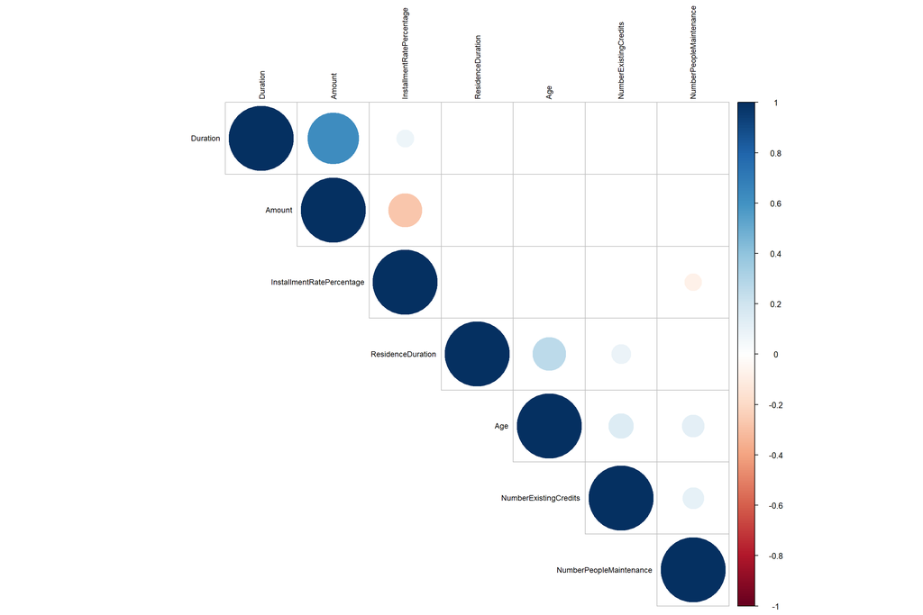

```r
##################################
# Reusing dataset
##################################
DQA.Numeric_ExcludedLowVariance <- DPA_ExcludedLowVariance[,sapply(DPA_ExcludedLowVariance, is.numeric)]
DPA.Predictors.Numeric <- DQA.Numeric_ExcludedLowVariance

##################################
# Visualizing pairwise correlation between predictors
##################################
DPA_CorrelationTest <- cor.mtest(DPA.Predictors.Numeric,
                       method = "pearson",
                       conf.level = .95)

corrplot(cor(DPA.Predictors.Numeric,
             method = "pearson",
             use="pairwise.complete.obs"),
         method = "circle",
         type = "upper",
         order = "original",
         tl.col = "black",
         tl.cex = 0.75,
         tl.srt = 90,
         sig.level = 0.05,
         p.mat = DPA_CorrelationTest$p,
         insig = "blank")
```

```r
##################################
# Identifying the highly correlated variables
##################################
DPA_Correlation <-  cor(DPA.Predictors.Numeric,
                        method = "pearson",
                        use="pairwise.complete.obs")
(DPA_HighlyCorrelatedCount <- sum(abs(DPA_Correlation[upper.tri(DPA_Correlation)]) > 0.95))
```

```
## [1] 0
```

```r
if (DPA_HighlyCorrelatedCount == 0) {
  print("No highly correlated predictors noted.")
} else {
  print(paste0("High correlation observed for ",
               (DPA_HighlyCorrelatedCount),
               " pairs of numeric variable(s) with Correlation.Coefficient>0.95."))

  (DPA_HighlyCorrelatedPairs <- corr_cross(DPA.Predictors.Numeric,
  max_pvalue = 0.05,
  top = DPA_HighlyCorrelatedCount,
  rm.na = TRUE,
  grid = FALSE
))

}
```

```
## [1] "No highly correlated predictors noted."
```

```r
if (DPA_HighlyCorrelatedCount > 0) {
  DPA_HighlyCorrelated <- findCorrelation(DPA_Correlation, cutoff = 0.95)

  (DPA_HighlyCorrelatedForRemoval <- length(DPA_HighlyCorrelated))

  print(paste0("High correlation can be resolved by removing ",
               (DPA_HighlyCorrelatedForRemoval),
               " numeric variable(s)."))

  for (j in 1:DPA_HighlyCorrelatedForRemoval) {
  DPA_HighlyCorrelatedRemovedVariable <- colnames(DPA.Predictors.Numeric)[DPA_HighlyCorrelated[j]]
  print(paste0("Variable ",
               j,
               " for removal: ",
               DPA_HighlyCorrelatedRemovedVariable))
  }

  ##################################
  # Filtering out columns with high correlation
  #################################
  DPA_ExcludedHighCorrelation <- DPA[,-DPA_HighlyCorrelated]

  ##################################
  # Gathering descriptive statistics
  ##################################
  (DPA_ExcludedHighCorrelation_Skimmed <- skim(DPA_ExcludedHighCorrelation))

}
```

### 1.3.4 Linear Dependencies

Linear dependency data assessment:  
**[A]** Linear dependencies noted for 4 subsets of variables using the preprocessing summary from the **caret** package applying the findLinearCombos method which utilizes the QR decomposition of a matrix to enumerate sets of linear combinations (if they exist). The following variables were recommended to be removed in order to resolve the linear dependency issue:  
**[A.1]** EmploymentDuration.Unemployed variable (factor)  
**[A.2]** Personal.Male.Married.Widowed variable (factor)  
**[A.3]** Property.Unknown variable (factor)  
**[A.4]** Housing.ForFree variable (factor)  
**[B]** There were 4 variables which consistently appeared across the 4 subsets. Among them, the CheckingAccountStatus.lt.0 variable was removed.  
**[B.1]** CheckingAccountStatus.lt.0 variable (factor)  
**[B.2]** CheckingAccountStatus.0.to.200 variable (factor)  
**[B.3]** CheckingAccountStatus.gt.200 variable (factor)  
**[B.4]** CheckingAccountStatus.none variable (factor)

**Code Chunk | Output**

```r
##################################
# Loading dataset
##################################
DPA <- GermanCredit
DPA_ExcludedLowVariance <- DPA[,!names(DPA) %in% rownames(DPA_LowVariance[DPA_LowVariance$nzv,])]

##################################
# Listing all predictors
##################################
DPA.Predictors <- DPA_ExcludedLowVariance[,!names(DPA_ExcludedLowVariance) %in% c("Class")]

##################################
# Listing all numeric predictors
##################################
DPA.Predictors.Numeric <- DPA.Predictors[,sapply(DPA.Predictors, is.numeric)]

##################################
# Finding linear dependencies
##################################
DPA_LinearlyDependent <- findLinearCombos(DPA.Predictors.Numeric)

##################################
# Identifying the linearly dependent variables
##################################
DPA_LinearlyDependent <- findLinearCombos(DPA.Predictors.Numeric)

(DPA_LinearlyDependentCount <- length(DPA_LinearlyDependent$linearCombos))
```

```
## [1] 4
```

```r
if (DPA_LinearlyDependentCount == 0) {
  print("No linearly dependent predictors noted.")
} else {
  print(paste0("Linear dependency observed for ",
               (DPA_LinearlyDependentCount),
               " subset(s) of numeric variable(s)."))

  for (i in 1:DPA_LinearlyDependentCount) {
    DPA_LinearlyDependentSubset <- colnames(DPA.Predictors.Numeric)[DPA_LinearlyDependent$linearCombos[[i]]]
    print(paste0("Linear dependent variable(s) for subset ",
                 i,
                 " include: ",
                 DPA_LinearlyDependentSubset))
  }

}
```

```
## [1] "Linear dependency observed for 4 subset(s) of numeric variable(s)."
## [1] "Linear dependent variable(s) for subset 1 include: EmploymentDuration.Unemployed"
## [2] "Linear dependent variable(s) for subset 1 include: CheckingAccountStatus.lt.0"
## [3] "Linear dependent variable(s) for subset 1 include: CheckingAccountStatus.0.to.200"
## [4] "Linear dependent variable(s) for subset 1 include: CheckingAccountStatus.gt.200"
## [5] "Linear dependent variable(s) for subset 1 include: CheckingAccountStatus.none"
## [6] "Linear dependent variable(s) for subset 1 include: EmploymentDuration.lt.1"
## [7] "Linear dependent variable(s) for subset 1 include: EmploymentDuration.1.to.4"
## [8] "Linear dependent variable(s) for subset 1 include: EmploymentDuration.4.to.7"
## [9] "Linear dependent variable(s) for subset 1 include: EmploymentDuration.gt.7"
## [1] "Linear dependent variable(s) for subset 2 include: Personal.Male.Married.Widowed"
## [2] "Linear dependent variable(s) for subset 2 include: CheckingAccountStatus.lt.0"
## [3] "Linear dependent variable(s) for subset 2 include: CheckingAccountStatus.0.to.200"
## [4] "Linear dependent variable(s) for subset 2 include: CheckingAccountStatus.gt.200"
## [5] "Linear dependent variable(s) for subset 2 include: CheckingAccountStatus.none"
```

[output cut: 18 more lines]

```r
##################################
# Identifying the linearly dependent variables for removal
##################################

if (DPA_LinearlyDependentCount > 0) {
  DPA_LinearlyDependent <- findLinearCombos(DPA.Predictors.Numeric)

  DPA_LinearlyDependentForRemoval <- length(DPA_LinearlyDependent$remove)

  print(paste0("Linear dependency can be resolved by removing ",
               (DPA_LinearlyDependentForRemoval),
               " numeric variable(s)."))

  for (j in 1:DPA_LinearlyDependentForRemoval) {
  DPA_LinearlyDependentRemovedVariable <- colnames(DPA.Predictors.Numeric)[DPA_LinearlyDependent$remove[j]]
  print(paste0("Variable ",
               j,
               " for removal: ",
               DPA_LinearlyDependentRemovedVariable))
  }

  ##################################
  # Filtering out columns with linear dependency
  #################################
  DPA_ExcludedLinearlyDependent <- DPA.Predictors.Numeric[,-DPA_LinearlyDependent$remove]

  ##################################
  # Gathering descriptive statistics
  ##################################
  (DPA_ExcludedLinearlyDependent_Skimmed <- skim(DPA_ExcludedLinearlyDependent))

}
```

```
## [1] "Linear dependency can be resolved by removing 4 numeric variable(s)."
## [1] "Variable 1 for removal: EmploymentDuration.Unemployed"
## [1] "Variable 2 for removal: Personal.Male.Married.Widowed"
## [1] "Variable 3 for removal: Property.Unknown"
## [1] "Variable 4 for removal: Housing.ForFree"
```

Data summary

| Name | DPA_ExcludedLinearlyDepen… |
| --- | --- |
| Number of rows | 1000 |
| Number of columns | 44 |
| _______________________ |  |
| Column type frequency: |  |
| numeric | 44 |
| ________________________ |  |
| Group variables | None |

**Variable type: numeric**

| skim_variable | n_missing | complete_rate | mean | sd | p0 | p25 | p50 | p75 | p100 | hist |
| --- | --- | --- | --- | --- | --- | --- | --- | --- | --- | --- |
| Duration | 0 | 1 | 20.90 | 12.06 | 4 | 12.0 | 18.0 | 24.00 | 72 | ▇▇▂▁▁ |
| Amount | 0 | 1 | 3271.26 | 2822.74 | 250 | 1365.5 | 2319.5 | 3972.25 | 18424 | ▇▂▁▁▁ |
| InstallmentRatePercentage | 0 | 1 | 2.97 | 1.12 | 1 | 2.0 | 3.0 | 4.00 | 4 | ▂▃▁▂▇ |
| ResidenceDuration | 0 | 1 | 2.85 | 1.10 | 1 | 2.0 | 3.0 | 4.00 | 4 | ▂▆▁▃▇ |
| Age | 0 | 1 | 35.55 | 11.38 | 19 | 27.0 | 33.0 | 42.00 | 75 | ▇▆▃▁▁ |
| NumberExistingCredits | 0 | 1 | 1.41 | 0.58 | 1 | 1.0 | 1.0 | 2.00 | 4 | ▇▅▁▁▁ |
| NumberPeopleMaintenance | 0 | 1 | 1.16 | 0.36 | 1 | 1.0 | 1.0 | 1.00 | 2 | ▇▁▁▁▂ |
| Telephone | 0 | 1 | 0.60 | 0.49 | 0 | 0.0 | 1.0 | 1.00 | 1 | ▆▁▁▁▇ |
| CheckingAccountStatus.lt.0 | 0 | 1 | 0.27 | 0.45 | 0 | 0.0 | 0.0 | 1.00 | 1 | ▇▁▁▁▃ |
| CheckingAccountStatus.0.to.200 | 0 | 1 | 0.27 | 0.44 | 0 | 0.0 | 0.0 | 1.00 | 1 | ▇▁▁▁▃ |
| CheckingAccountStatus.gt.200 | 0 | 1 | 0.06 | 0.24 | 0 | 0.0 | 0.0 | 0.00 | 1 | ▇▁▁▁▁ |
| CheckingAccountStatus.none | 0 | 1 | 0.39 | 0.49 | 0 | 0.0 | 0.0 | 1.00 | 1 | ▇▁▁▁▅ |
| CreditHistory.PaidDuly | 0 | 1 | 0.53 | 0.50 | 0 | 0.0 | 1.0 | 1.00 | 1 | ▇▁▁▁▇ |
| CreditHistory.Delay | 0 | 1 | 0.09 | 0.28 | 0 | 0.0 | 0.0 | 0.00 | 1 | ▇▁▁▁▁ |
| CreditHistory.Critical | 0 | 1 | 0.29 | 0.46 | 0 | 0.0 | 0.0 | 1.00 | 1 | ▇▁▁▁▃ |
| Purpose.NewCar | 0 | 1 | 0.23 | 0.42 | 0 | 0.0 | 0.0 | 0.00 | 1 | ▇▁▁▁▂ |
| Purpose.UsedCar | 0 | 1 | 0.10 | 0.30 | 0 | 0.0 | 0.0 | 0.00 | 1 | ▇▁▁▁▁ |
| Purpose.Furniture.Equipment | 0 | 1 | 0.18 | 0.39 | 0 | 0.0 | 0.0 | 0.00 | 1 | ▇▁▁▁▂ |
| Purpose.Radio.Television | 0 | 1 | 0.28 | 0.45 | 0 | 0.0 | 0.0 | 1.00 | 1 | ▇▁▁▁▃ |
| Purpose.Education | 0 | 1 | 0.05 | 0.22 | 0 | 0.0 | 0.0 | 0.00 | 1 | ▇▁▁▁▁ |
| Purpose.Business | 0 | 1 | 0.10 | 0.30 | 0 | 0.0 | 0.0 | 0.00 | 1 | ▇▁▁▁▁ |
| SavingsAccountBonds.lt.100 | 0 | 1 | 0.60 | 0.49 | 0 | 0.0 | 1.0 | 1.00 | 1 | ▅▁▁▁▇ |
| SavingsAccountBonds.100.to.500 | 0 | 1 | 0.10 | 0.30 | 0 | 0.0 | 0.0 | 0.00 | 1 | ▇▁▁▁▁ |
| SavingsAccountBonds.500.to.1000 | 0 | 1 | 0.06 | 0.24 | 0 | 0.0 | 0.0 | 0.00 | 1 | ▇▁▁▁▁ |
| SavingsAccountBonds.Unknown | 0 | 1 | 0.18 | 0.39 | 0 | 0.0 | 0.0 | 0.00 | 1 | ▇▁▁▁▂ |
| EmploymentDuration.lt.1 | 0 | 1 | 0.17 | 0.38 | 0 | 0.0 | 0.0 | 0.00 | 1 | ▇▁▁▁▂ |
| EmploymentDuration.1.to.4 | 0 | 1 | 0.34 | 0.47 | 0 | 0.0 | 0.0 | 1.00 | 1 | ▇▁▁▁▅ |
| EmploymentDuration.4.to.7 | 0 | 1 | 0.17 | 0.38 | 0 | 0.0 | 0.0 | 0.00 | 1 | ▇▁▁▁▂ |
| EmploymentDuration.gt.7 | 0 | 1 | 0.25 | 0.43 | 0 | 0.0 | 0.0 | 1.00 | 1 | ▇▁▁▁▃ |
| Personal.Male.Divorced.Seperated | 0 | 1 | 0.05 | 0.22 | 0 | 0.0 | 0.0 | 0.00 | 1 | ▇▁▁▁▁ |
| Personal.Female.NotSingle | 0 | 1 | 0.31 | 0.46 | 0 | 0.0 | 0.0 | 1.00 | 1 | ▇▁▁▁▃ |
| Personal.Male.Single | 0 | 1 | 0.55 | 0.50 | 0 | 0.0 | 1.0 | 1.00 | 1 | ▆▁▁▁▇ |
| OtherDebtorsGuarantors.None | 0 | 1 | 0.91 | 0.29 | 0 | 1.0 | 1.0 | 1.00 | 1 | ▁▁▁▁▇ |
| OtherDebtorsGuarantors.Guarantor | 0 | 1 | 0.05 | 0.22 | 0 | 0.0 | 0.0 | 0.00 | 1 | ▇▁▁▁▁ |
| Property.RealEstate | 0 | 1 | 0.28 | 0.45 | 0 | 0.0 | 0.0 | 1.00 | 1 | ▇▁▁▁▃ |
| Property.Insurance | 0 | 1 | 0.23 | 0.42 | 0 | 0.0 | 0.0 | 0.00 | 1 | ▇▁▁▁▂ |
| Property.CarOther | 0 | 1 | 0.33 | 0.47 | 0 | 0.0 | 0.0 | 1.00 | 1 | ▇▁▁▁▃ |
| OtherInstallmentPlans.Bank | 0 | 1 | 0.14 | 0.35 | 0 | 0.0 | 0.0 | 0.00 | 1 | ▇▁▁▁▁ |
| OtherInstallmentPlans.None | 0 | 1 | 0.81 | 0.39 | 0 | 1.0 | 1.0 | 1.00 | 1 | ▂▁▁▁▇ |
| Housing.Rent | 0 | 1 | 0.18 | 0.38 | 0 | 0.0 | 0.0 | 0.00 | 1 | ▇▁▁▁▂ |
| Housing.Own | 0 | 1 | 0.71 | 0.45 | 0 | 0.0 | 1.0 | 1.00 | 1 | ▃▁▁▁▇ |
| Job.UnskilledResident | 0 | 1 | 0.20 | 0.40 | 0 | 0.0 | 0.0 | 0.00 | 1 | ▇▁▁▁▂ |
| Job.SkilledEmployee | 0 | 1 | 0.63 | 0.48 | 0 | 0.0 | 1.0 | 1.00 | 1 | ▅▁▁▁▇ |
| Job.Management.SelfEmp.HighlyQualified | 0 | 1 | 0.15 | 0.36 | 0 | 0.0 | 0.0 | 0.00 | 1 | ▇▁▁▁▂ |

### 1.3.5 Pre-Processed Dataset

**Code Chunk | Output**

```r
##################################
# Creating the pre-modelling dataset
#################################
PMA_ExcludedLowVariance <- PMA

##################################
# Filtering out columns with linear dependencies
# from the dataset with low-variance columns already filtered
# to create the pre-modelling dataset
#################################
PMA_ExcludedLowVariance$CheckingAccountStatus.lt.0 <- NULL
PMA_ExcludedLowVariance$EmploymentDuration.Unemployed <- NULL
PMA_ExcludedLowVariance$Personal.Male.Married.Widowed <- NULL
PMA_ExcludedLowVariance$Property.Unknown <- NULL
PMA_ExcludedLowVariance$Housing.ForFree <- NULL

PMA_ExcludedLowVariance_ExcludedLinearlyDependent <- PMA_ExcludedLowVariance

PMA_PreModelling <- PMA_ExcludedLowVariance_ExcludedLinearlyDependent

##################################
# Gathering descriptive statistics
##################################
(PMA_PreModelling_Skimmed <- skim(PMA_PreModelling))
```

Data summary

| Name | PMA_PreModelling |
| --- | --- |
| Number of rows | 1000 |
| Number of columns | 44 |
| _______________________ |  |
| Column type frequency: |  |
| factor | 37 |
| numeric | 7 |
| ________________________ |  |
| Group variables | None |

**Variable type: factor**

| skim_variable | n_missing | complete_rate | ordered | n_unique | top_counts |
| --- | --- | --- | --- | --- | --- |
| Telephone | 0 | 1 | FALSE | 2 | 1: 596, 0: 404 |
| Class | 0 | 1 | FALSE | 2 | Goo: 700, Bad: 300 |
| CheckingAccountStatus.0.to.200 | 0 | 1 | FALSE | 2 | 0: 731, 1: 269 |
| CheckingAccountStatus.gt.200 | 0 | 1 | FALSE | 2 | 0: 937, 1: 63 |
| CheckingAccountStatus.none | 0 | 1 | FALSE | 2 | 0: 606, 1: 394 |
| CreditHistory.PaidDuly | 0 | 1 | FALSE | 2 | 1: 530, 0: 470 |
| CreditHistory.Delay | 0 | 1 | FALSE | 2 | 0: 912, 1: 88 |
| CreditHistory.Critical | 0 | 1 | FALSE | 2 | 0: 707, 1: 293 |
| Purpose.NewCar | 0 | 1 | FALSE | 2 | 0: 766, 1: 234 |
| Purpose.UsedCar | 0 | 1 | FALSE | 2 | 0: 897, 1: 103 |
| Purpose.Furniture.Equipment | 0 | 1 | FALSE | 2 | 0: 819, 1: 181 |
| Purpose.Radio.Television | 0 | 1 | FALSE | 2 | 0: 720, 1: 280 |
| Purpose.Education | 0 | 1 | FALSE | 2 | 0: 950, 1: 50 |
| Purpose.Business | 0 | 1 | FALSE | 2 | 0: 903, 1: 97 |
| SavingsAccountBonds.lt.100 | 0 | 1 | FALSE | 2 | 1: 603, 0: 397 |
| SavingsAccountBonds.100.to.500 | 0 | 1 | FALSE | 2 | 0: 897, 1: 103 |
| SavingsAccountBonds.500.to.1000 | 0 | 1 | FALSE | 2 | 0: 937, 1: 63 |
| SavingsAccountBonds.Unknown | 0 | 1 | FALSE | 2 | 0: 817, 1: 183 |
| EmploymentDuration.lt.1 | 0 | 1 | FALSE | 2 | 0: 828, 1: 172 |
| EmploymentDuration.1.to.4 | 0 | 1 | FALSE | 2 | 0: 661, 1: 339 |
| EmploymentDuration.4.to.7 | 0 | 1 | FALSE | 2 | 0: 826, 1: 174 |
| EmploymentDuration.gt.7 | 0 | 1 | FALSE | 2 | 0: 747, 1: 253 |
| Personal.Male.Divorced.Seperated | 0 | 1 | FALSE | 2 | 0: 950, 1: 50 |
| Personal.Female.NotSingle | 0 | 1 | FALSE | 2 | 0: 690, 1: 310 |
| Personal.Male.Single | 0 | 1 | FALSE | 2 | 1: 548, 0: 452 |
| OtherDebtorsGuarantors.None | 0 | 1 | FALSE | 2 | 1: 907, 0: 93 |
| OtherDebtorsGuarantors.Guarantor | 0 | 1 | FALSE | 2 | 0: 948, 1: 52 |
| Property.RealEstate | 0 | 1 | FALSE | 2 | 0: 718, 1: 282 |
| Property.Insurance | 0 | 1 | FALSE | 2 | 0: 768, 1: 232 |
| Property.CarOther | 0 | 1 | FALSE | 2 | 0: 668, 1: 332 |
| OtherInstallmentPlans.Bank | 0 | 1 | FALSE | 2 | 0: 861, 1: 139 |
| OtherInstallmentPlans.None | 0 | 1 | FALSE | 2 | 1: 814, 0: 186 |
| Housing.Rent | 0 | 1 | FALSE | 2 | 0: 821, 1: 179 |
| Housing.Own | 0 | 1 | FALSE | 2 | 1: 713, 0: 287 |
| Job.UnskilledResident | 0 | 1 | FALSE | 2 | 0: 800, 1: 200 |
| Job.SkilledEmployee | 0 | 1 | FALSE | 2 | 1: 630, 0: 370 |
| Job.Management.SelfEmp.HighlyQualified | 0 | 1 | FALSE | 2 | 0: 852, 1: 148 |

**Variable type: numeric**

| skim_variable | n_missing | complete_rate | mean | sd | p0 | p25 | p50 | p75 | p100 | hist |
| --- | --- | --- | --- | --- | --- | --- | --- | --- | --- | --- |
| Duration | 0 | 1 | 20.90 | 12.06 | 4 | 12.0 | 18.0 | 24.00 | 72 | ▇▇▂▁▁ |
| Amount | 0 | 1 | 3271.26 | 2822.74 | 250 | 1365.5 | 2319.5 | 3972.25 | 18424 | ▇▂▁▁▁ |
| InstallmentRatePercentage | 0 | 1 | 2.97 | 1.12 | 1 | 2.0 | 3.0 | 4.00 | 4 | ▂▃▁▂▇ |
| ResidenceDuration | 0 | 1 | 2.85 | 1.10 | 1 | 2.0 | 3.0 | 4.00 | 4 | ▂▆▁▃▇ |
| Age | 0 | 1 | 35.55 | 11.38 | 19 | 27.0 | 33.0 | 42.00 | 75 | ▇▆▃▁▁ |
| NumberExistingCredits | 0 | 1 | 1.41 | 0.58 | 1 | 1.0 | 1.0 | 2.00 | 4 | ▇▅▁▁▁ |
| NumberPeopleMaintenance | 0 | 1 | 1.16 | 0.36 | 1 | 1.0 | 1.0 | 1.00 | 2 | ▇▁▁▁▂ |

## 1.4 Data Exploration

Exploratory data analysis:  
**[A]** Variables which demonstrated relatively better differentiation between the Bad and Good levels of the response variable Class include:  
**[A.1]** Duration variable (numeric)  
**[A.2]** CheckingAccountStatus.none variable (factor)  
**[A.3]** CreditHistory.Critical variable (factor)  
**[A.4]** Purpose.UsedCar variable (factor)  
**[A.5]** SavingsAccountsBonds.lt.100 variable (factor)  
**[A.6]** SavingsAccountsBonds.500.to.1000 variable (factor)  
**[A.7]** SavingsAccountsBonds.Unknown variable (factor)  
**[A.8]** EmploymentDuration.4to7 variable (factor)  
**[A.9]** Personal.Male.Divorced.Separated variable (factor)  
**[A.10]** OtherDebtorsGuarantors.Guarantor variable (factor)  
**[A.11]** Property.RealEstate variable (factor)  
**[A.12]** OtherInstallmentPlans.Bank variable (factor)  
**[A.13]** OtherInstallmentPlans.None variable (factor)  
**[A.14]** Housing.Rent variable (factor)  
**[A.15]** Housing.Own variable (factor)

**Code Chunk | Output**

```r
##################################
# Loading dataset
##################################
EDA <- PMA_PreModelling

##################################
# Listing all predictors
##################################
EDA.Predictors <- EDA[,!names(EDA) %in% c("Class")]

##################################
# Listing all numeric predictors
##################################
EDA.Predictors.Numeric <- EDA.Predictors[,sapply(EDA.Predictors, is.numeric)]
ncol(EDA.Predictors.Numeric)
```

```
## [1] 7
```

```r
names(EDA.Predictors.Numeric)
```

```
## [1] "Duration"                  "Amount"
## [3] "InstallmentRatePercentage" "ResidenceDuration"
## [5] "Age"                       "NumberExistingCredits"
## [7] "NumberPeopleMaintenance"
```

```r
##################################
# Converting response variable data type to factor
##################################
EDA$Class <- as.factor(EDA$Class)
length(levels(EDA$Class))
```

```
## [1] 2
```

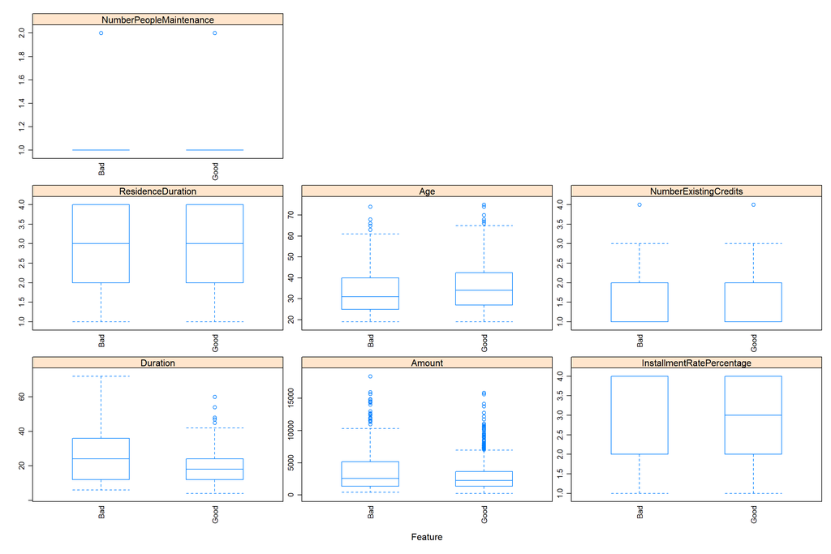

```r
##################################
# Formulating the box plots
##################################
featurePlot(x = EDA.Predictors.Numeric,
            y = EDA$Class,
            plot = "box",
            scales = list(x = list(relation="free", rot = 90),
                          y = list(relation="free")),
            adjust = 1.5,
            pch = "|",
            layout = c(3, 3))
```

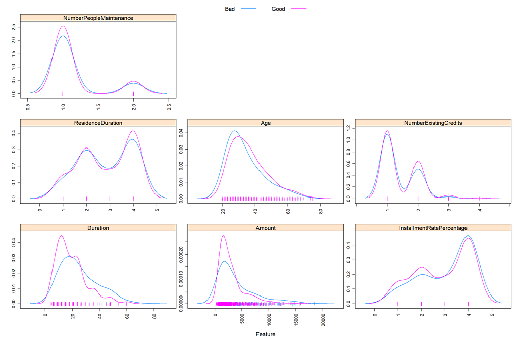

```r
##################################
# Formulating the density plots
##################################
featurePlot(x = EDA.Predictors.Numeric,
            y = EDA$Class,
            plot = "density",
            scales = list(x = list(relation="free", rot = 90),
                          y = list(relation="free")),
            adjust = 1.5,
            pch = "|",
            layout = c(3, 3),
            auto.key = list(columns = (length(levels(EDA$Class)))))
```

```r
##################################
# Listing all factor predictors
##################################
EDA.Predictors.Factor <- EDA.Predictors[,sapply(EDA.Predictors, is.factor)]
ncol(EDA.Predictors.Factor)
```

```
## [1] 36
```

```r
names(EDA.Predictors.Factor)
```

```
##  [1] "Telephone"
##  [2] "CheckingAccountStatus.0.to.200"
##  [3] "CheckingAccountStatus.gt.200"
##  [4] "CheckingAccountStatus.none"
##  [5] "CreditHistory.PaidDuly"
##  [6] "CreditHistory.Delay"
##  [7] "CreditHistory.Critical"
##  [8] "Purpose.NewCar"
##  [9] "Purpose.UsedCar"
## [10] "Purpose.Furniture.Equipment"
## [11] "Purpose.Radio.Television"
## [12] "Purpose.Education"
## [13] "Purpose.Business"
## [14] "SavingsAccountBonds.lt.100"
## [15] "SavingsAccountBonds.100.to.500"
```

[output cut: 21 more lines]

```r
##################################
# Formulating the proportion tables
##################################
Prop_Label <- names(EDA.Predictors.Factor)[1]
PropTable_Label <- paste0(Prop_Label,"_PropTable")
PropTable_Data <- EDA[,c("Class",Prop_Label)]
PropTable_Summary <- (assign(PropTable_Label,as.data.frame(prop.table(table(PropTable_Data), 2))))
PropTable_Summary$Variable <- rep(Prop_Label,nrow(PropTable_Summary))
PropTable_Summary$Category <- PropTable_Summary[,2]

PropTable_BarChart_1 <- barchart(Freq ~ Category | Variable,
         data=PropTable_Summary,
         groups = Class,
         stack=TRUE,
         ylab = "Proportion",
         auto.key = list(adj = 1))

Prop_Label <- names(EDA.Predictors.Factor)[2]
PropTable_Label <- paste0(Prop_Label,"_PropTable")
PropTable_Data <- EDA[,c("Class",Prop_Label)]
PropTable_Summary <- (assign(PropTable_Label,as.data.frame(prop.table(table(PropTable_Data), 2))))
PropTable_Summary$Variable <- rep(Prop_Label,nrow(PropTable_Summary))
PropTable_Summary$Category <- PropTable_Summary[,2]

PropTable_BarChart_2 <- barchart(Freq ~ Category | Variable,
         data=PropTable_Summary,
         groups = Class,
         stack=TRUE,
         ylab = "Proportion",
         auto.key = list(adj = 1))

Prop_Label <- names(EDA.Predictors.Factor)[3]
PropTable_Label <- paste0(Prop_Label,"_PropTable")
PropTable_Data <- EDA[,c("Class",Prop_Label)]
PropTable_Summary <- (assign(PropTable_Label,as.data.frame(prop.table(table(PropTable_Data), 2))))
PropTable_Summary$Variable <- rep(Prop_Label,nrow(PropTable_Summary))
PropTable_Summary$Category <- PropTable_Summary[,2]

PropTable_BarChart_3 <- barchart(Freq ~ Category | Variable,
         data=PropTable_Summary,
         groups = Class,
         stack=TRUE,
         ylab = "Proportion",
         auto.key = list(adj = 1))

Prop_Label <- names(EDA.Predictors.Factor)[4]
PropTable_Label <- paste0(Prop_Label,"_PropTable")
PropTable_Data <- EDA[,c("Class",Prop_Label)]
PropTable_Summary <- (assign(PropTable_Label,as.data.frame(prop.table(table(PropTable_Data), 2))))
PropTable_Summary$Variable <- rep(Prop_Label,nrow(PropTable_Summary))
PropTable_Summary$Category <- PropTable_Summary[,2]

PropTable_BarChart_4 <- barchart(Freq ~ Category | Variable,
         data=PropTable_Summary,
         groups = Class,
         stack=TRUE,
         ylab = "Proportion",
         auto.key = list(adj = 1))

Prop_Label <- names(EDA.Predictors.Factor)[5]
PropTable_Label <- paste0(Prop_Label,"_PropTable")
PropTable_Data <- EDA[,c("Class",Prop_Label)]
PropTable_Summary <- (assign(PropTable_Label,as.data.frame(prop.table(table(PropTable_Data), 2))))
PropTable_Summary$Variable <- rep(Prop_Label,nrow(PropTable_Summary))
PropTable_Summary$Category <- PropTable_Summary[,2]

PropTable_BarChart_5 <- barchart(Freq ~ Category | Variable,
         data=PropTable_Summary,
         groups = Class,
         stack=TRUE,
         ylab = "Proportion",
         auto.key = list(adj = 1))

Prop_Label <- names(EDA.Predictors.Factor)[6]
PropTable_Label <- paste0(Prop_Label,"_PropTable")
PropTable_Data <- EDA[,c("Class",Prop_Label)]
PropTable_Summary <- (assign(PropTable_Label,as.data.frame(prop.table(table(PropTable_Data), 2))))
PropTable_Summary$Variable <- rep(Prop_Label,nrow(PropTable_Summary))
PropTable_Summary$Category <- PropTable_Summary[,2]

PropTable_BarChart_6 <- barchart(Freq ~ Category | Variable,
         data=PropTable_Summary,
         groups = Class,
         stack=TRUE,
         ylab = "Proportion",
         auto.key = list(adj = 1))

Prop_Label <- names(EDA.Predictors.Factor)[7]
PropTable_Label <- paste0(Prop_Label,"_PropTable")
PropTable_Data <- EDA[,c("Class",Prop_Label)]
PropTable_Summary <- (assign(PropTable_Label,as.data.frame(prop.table(table(PropTable_Data), 2))))
PropTable_Summary$Variable <- rep(Prop_Label,nrow(PropTable_Summary))
PropTable_Summary$Category <- PropTable_Summary[,2]

PropTable_BarChart_7 <- barchart(Freq ~ Category | Variable,
         data=PropTable_Summary,
         groups = Class,
         stack=TRUE,
         ylab = "Proportion",
         auto.key = list(adj = 1))

Prop_Label <- names(EDA.Predictors.Factor)[8]
PropTable_Label <- paste0(Prop_Label,"_PropTable")
PropTable_Data <- EDA[,c("Class",Prop_Label)]
PropTable_Summary <- (assign(PropTable_Label,as.data.frame(prop.table(table(PropTable_Data), 2))))
PropTable_Summary$Variable <- rep(Prop_Label,nrow(PropTable_Summary))
PropTable_Summary$Category <- PropTable_Summary[,2]

PropTable_BarChart_8 <- barchart(Freq ~ Category | Variable,
         data=PropTable_Summary,
         groups = Class,
         stack=TRUE,
         ylab = "Proportion",
         auto.key = list(adj = 1))

Prop_Label <- names(EDA.Predictors.Factor)[9]
PropTable_Label <- paste0(Prop_Label,"_PropTable")
PropTable_Data <- EDA[,c("Class",Prop_Label)]
PropTable_Summary <- (assign(PropTable_Label,as.data.frame(prop.table(table(PropTable_Data), 2))))
PropTable_Summary$Variable <- rep(Prop_Label,nrow(PropTable_Summary))
PropTable_Summary$Category <- PropTable_Summary[,2]

PropTable_BarChart_9 <- barchart(Freq ~ Category | Variable,
         data=PropTable_Summary,
         groups = Class,
         stack=TRUE,
         ylab = "Proportion",
         auto.key = list(adj = 1))

Prop_Label <- names(EDA.Predictors.Factor)[10]
PropTable_Label <- paste0(Prop_Label,"_PropTable")
PropTable_Data <- EDA[,c("Class",Prop_Label)]
PropTable_Summary <- (assign(PropTable_Label,as.data.frame(prop.table(table(PropTable_Data), 2))))
PropTable_Summary$Variable <- rep(Prop_Label,nrow(PropTable_Summary))
PropTable_Summary$Category <- PropTable_Summary[,2]

PropTable_BarChart_10 <- barchart(Freq ~ Category | Variable,
         data=PropTable_Summary,
         groups = Class,
         stack=TRUE,
         ylab = "Proportion",
         auto.key = list(adj = 1))

Prop_Label <- names(EDA.Predictors.Factor)[11]
PropTable_Label <- paste0(Prop_Label,"_PropTable")
PropTable_Data <- EDA[,c("Class",Prop_Label)]
PropTable_Summary <- (assign(PropTable_Label,as.data.frame(prop.table(table(PropTable_Data), 2))))
PropTable_Summary$Variable <- rep(Prop_Label,nrow(PropTable_Summary))
PropTable_Summary$Category <- PropTable_Summary[,2]
```

```r
PropTable_BarChart_11 <- barchart(Freq ~ Category | Variable,
         data=PropTable_Summary,
         groups = Class,
         stack=TRUE,
         ylab = "Proportion",
         auto.key = list(adj = 1))

Prop_Label <- names(EDA.Predictors.Factor)[12]
PropTable_Label <- paste0(Prop_Label,"_PropTable")
PropTable_Data <- EDA[,c("Class",Prop_Label)]
PropTable_Summary <- (assign(PropTable_Label,as.data.frame(prop.table(table(PropTable_Data), 2))))
PropTable_Summary$Variable <- rep(Prop_Label,nrow(PropTable_Summary))
PropTable_Summary$Category <- PropTable_Summary[,2]

PropTable_BarChart_12 <- barchart(Freq ~ Category | Variable,
         data=PropTable_Summary,
         groups = Class,
         stack=TRUE,
         ylab = "Proportion",
         auto.key = list(adj = 1))

Prop_Label <- names(EDA.Predictors.Factor)[13]
PropTable_Label <- paste0(Prop_Label,"_PropTable")
PropTable_Data <- EDA[,c("Class",Prop_Label)]
PropTable_Summary <- (assign(PropTable_Label,as.data.frame(prop.table(table(PropTable_Data), 2))))
PropTable_Summary$Variable <- rep(Prop_Label,nrow(PropTable_Summary))
PropTable_Summary$Category <- PropTable_Summary[,2]

PropTable_BarChart_13 <- barchart(Freq ~ Category | Variable,
         data=PropTable_Summary,
         groups = Class,
         stack=TRUE,
         ylab = "Proportion",
         auto.key = list(adj = 1))

Prop_Label <- names(EDA.Predictors.Factor)[14]
PropTable_Label <- paste0(Prop_Label,"_PropTable")
PropTable_Data <- EDA[,c("Class",Prop_Label)]
PropTable_Summary <- (assign(PropTable_Label,as.data.frame(prop.table(table(PropTable_Data), 2))))
PropTable_Summary$Variable <- rep(Prop_Label,nrow(PropTable_Summary))
PropTable_Summary$Category <- PropTable_Summary[,2]

PropTable_BarChart_14 <- barchart(Freq ~ Category | Variable,
         data=PropTable_Summary,
         groups = Class,
         stack=TRUE,
         ylab = "Proportion",
         auto.key = list(adj = 1))

Prop_Label <- names(EDA.Predictors.Factor)[15]
PropTable_Label <- paste0(Prop_Label,"_PropTable")
PropTable_Data <- EDA[,c("Class",Prop_Label)]
PropTable_Summary <- (assign(PropTable_Label,as.data.frame(prop.table(table(PropTable_Data), 2))))
PropTable_Summary$Variable <- rep(Prop_Label,nrow(PropTable_Summary))
PropTable_Summary$Category <- PropTable_Summary[,2]

PropTable_BarChart_15 <- barchart(Freq ~ Category | Variable,
         data=PropTable_Summary,
         groups = Class,
         stack=TRUE,
         ylab = "Proportion",
         auto.key = list(adj = 1))

Prop_Label <- names(EDA.Predictors.Factor)[16]
PropTable_Label <- paste0(Prop_Label,"_PropTable")
PropTable_Data <- EDA[,c("Class",Prop_Label)]
PropTable_Summary <- (assign(PropTable_Label,as.data.frame(prop.table(table(PropTable_Data), 2))))
PropTable_Summary$Variable <- rep(Prop_Label,nrow(PropTable_Summary))
PropTable_Summary$Category <- PropTable_Summary[,2]

PropTable_BarChart_16 <- barchart(Freq ~ Category | Variable,
         data=PropTable_Summary,
         groups = Class,
         stack=TRUE,
         ylab = "Proportion",
         auto.key = list(adj = 1))

Prop_Label <- names(EDA.Predictors.Factor)[17]
PropTable_Label <- paste0(Prop_Label,"_PropTable")
PropTable_Data <- EDA[,c("Class",Prop_Label)]
PropTable_Summary <- (assign(PropTable_Label,as.data.frame(prop.table(table(PropTable_Data), 2))))
PropTable_Summary$Variable <- rep(Prop_Label,nrow(PropTable_Summary))
PropTable_Summary$Category <- PropTable_Summary[,2]

PropTable_BarChart_17 <- barchart(Freq ~ Category | Variable,
         data=PropTable_Summary,
         groups = Class,
         stack=TRUE,
         ylab = "Proportion",
         auto.key = list(adj = 1))

Prop_Label <- names(EDA.Predictors.Factor)[18]
PropTable_Label <- paste0(Prop_Label,"_PropTable")
PropTable_Data <- EDA[,c("Class",Prop_Label)]
PropTable_Summary <- (assign(PropTable_Label,as.data.frame(prop.table(table(PropTable_Data), 2))))
PropTable_Summary$Variable <- rep(Prop_Label,nrow(PropTable_Summary))
PropTable_Summary$Category <- PropTable_Summary[,2]

PropTable_BarChart_18 <- barchart(Freq ~ Category | Variable,
         data=PropTable_Summary,
         groups = Class,
         stack=TRUE,
         ylab = "Proportion",
         auto.key = list(adj = 1))

Prop_Label <- names(EDA.Predictors.Factor)[19]
PropTable_Label <- paste0(Prop_Label,"_PropTable")
PropTable_Data <- EDA[,c("Class",Prop_Label)]
PropTable_Summary <- (assign(PropTable_Label,as.data.frame(prop.table(table(PropTable_Data), 2))))
PropTable_Summary$Variable <- rep(Prop_Label,nrow(PropTable_Summary))
PropTable_Summary$Category <- PropTable_Summary[,2]

PropTable_BarChart_19 <- barchart(Freq ~ Category | Variable,
         data=PropTable_Summary,
         groups = Class,
         stack=TRUE,
         ylab = "Proportion",
         auto.key = list(adj = 1))

Prop_Label <- names(EDA.Predictors.Factor)[20]
PropTable_Label <- paste0(Prop_Label,"_PropTable")
PropTable_Data <- EDA[,c("Class",Prop_Label)]
PropTable_Summary <- (assign(PropTable_Label,as.data.frame(prop.table(table(PropTable_Data), 2))))
PropTable_Summary$Variable <- rep(Prop_Label,nrow(PropTable_Summary))
PropTable_Summary$Category <- PropTable_Summary[,2]

PropTable_BarChart_20 <- barchart(Freq ~ Category | Variable,
         data=PropTable_Summary,
         groups = Class,
         stack=TRUE,
         ylab = "Proportion",
         auto.key = list(adj = 1))

Prop_Label <- names(EDA.Predictors.Factor)[21]
PropTable_Label <- paste0(Prop_Label,"_PropTable")
PropTable_Data <- EDA[,c("Class",Prop_Label)]
PropTable_Summary <- (assign(PropTable_Label,as.data.frame(prop.table(table(PropTable_Data), 2))))
PropTable_Summary$Variable <- rep(Prop_Label,nrow(PropTable_Summary))
PropTable_Summary$Category <- PropTable_Summary[,2]

PropTable_BarChart_21 <- barchart(Freq ~ Category | Variable,
         data=PropTable_Summary,
         groups = Class,
         stack=TRUE,
         ylab = "Proportion",
         auto.key = list(adj = 1))

Prop_Label <- names(EDA.Predictors.Factor)[22]
PropTable_Label <- paste0(Prop_Label,"_PropTable")
PropTable_Data <- EDA[,c("Class",Prop_Label)]
PropTable_Summary <- (assign(PropTable_Label,as.data.frame(prop.table(table(PropTable_Data), 2))))
PropTable_Summary$Variable <- rep(Prop_Label,nrow(PropTable_Summary))
PropTable_Summary$Category <- PropTable_Summary[,2]
```

```r
PropTable_BarChart_22 <- barchart(Freq ~ Category | Variable,
         data=PropTable_Summary,
         groups = Class,
         stack=TRUE,
         ylab = "Proportion",
         auto.key = list(adj = 1))

Prop_Label <- names(EDA.Predictors.Factor)[23]
PropTable_Label <- paste0(Prop_Label,"_PropTable")
PropTable_Data <- EDA[,c("Class",Prop_Label)]
PropTable_Summary <- (assign(PropTable_Label,as.data.frame(prop.table(table(PropTable_Data), 2))))
PropTable_Summary$Variable <- rep(Prop_Label,nrow(PropTable_Summary))
PropTable_Summary$Category <- PropTable_Summary[,2]

PropTable_BarChart_23 <- barchart(Freq ~ Category | Variable,
         data=PropTable_Summary,
         groups = Class,
         stack=TRUE,
         ylab = "Proportion",
         auto.key = list(adj = 1))

Prop_Label <- names(EDA.Predictors.Factor)[24]
PropTable_Label <- paste0(Prop_Label,"_PropTable")
PropTable_Data <- EDA[,c("Class",Prop_Label)]
PropTable_Summary <- (assign(PropTable_Label,as.data.frame(prop.table(table(PropTable_Data), 2))))
PropTable_Summary$Variable <- rep(Prop_Label,nrow(PropTable_Summary))
PropTable_Summary$Category <- PropTable_Summary[,2]

PropTable_BarChart_24 <- barchart(Freq ~ Category | Variable,
         data=PropTable_Summary,
         groups = Class,
         stack=TRUE,
         ylab = "Proportion",
         auto.key = list(adj = 1))

Prop_Label <- names(EDA.Predictors.Factor)[25]
PropTable_Label <- paste0(Prop_Label,"_PropTable")
PropTable_Data <- EDA[,c("Class",Prop_Label)]
PropTable_Summary <- (assign(PropTable_Label,as.data.frame(prop.table(table(PropTable_Data), 2))))
PropTable_Summary$Variable <- rep(Prop_Label,nrow(PropTable_Summary))
PropTable_Summary$Category <- PropTable_Summary[,2]

PropTable_BarChart_25 <- barchart(Freq ~ Category | Variable,
         data=PropTable_Summary,
         groups = Class,
         stack=TRUE,
         ylab = "Proportion",
         auto.key = list(adj = 1))

Prop_Label <- names(EDA.Predictors.Factor)[26]
PropTable_Label <- paste0(Prop_Label,"_PropTable")
PropTable_Data <- EDA[,c("Class",Prop_Label)]
PropTable_Summary <- (assign(PropTable_Label,as.data.frame(prop.table(table(PropTable_Data), 2))))
PropTable_Summary$Variable <- rep(Prop_Label,nrow(PropTable_Summary))
PropTable_Summary$Category <- PropTable_Summary[,2]

PropTable_BarChart_26 <- barchart(Freq ~ Category | Variable,
         data=PropTable_Summary,
         groups = Class,
         stack=TRUE,
         ylab = "Proportion",
         auto.key = list(adj = 1))


Prop_Label <- names(EDA.Predictors.Factor)[27]
PropTable_Label <- paste0(Prop_Label,"_PropTable")
PropTable_Data <- EDA[,c("Class",Prop_Label)]
PropTable_Summary <- (assign(PropTable_Label,as.data.frame(prop.table(table(PropTable_Data), 2))))
PropTable_Summary$Variable <- rep(Prop_Label,nrow(PropTable_Summary))
PropTable_Summary$Category <- PropTable_Summary[,2]

PropTable_BarChart_27 <- barchart(Freq ~ Category | Variable,
         data=PropTable_Summary,
         groups = Class,
         stack=TRUE,
         ylab = "Proportion",
         auto.key = list(adj = 1))

Prop_Label <- names(EDA.Predictors.Factor)[28]
PropTable_Label <- paste0(Prop_Label,"_PropTable")
PropTable_Data <- EDA[,c("Class",Prop_Label)]
PropTable_Summary <- (assign(PropTable_Label,as.data.frame(prop.table(table(PropTable_Data), 2))))
PropTable_Summary$Variable <- rep(Prop_Label,nrow(PropTable_Summary))
PropTable_Summary$Category <- PropTable_Summary[,2]

PropTable_BarChart_28 <- barchart(Freq ~ Category | Variable,
         data=PropTable_Summary,
         groups = Class,
         stack=TRUE,
         ylab = "Proportion",
         auto.key = list(adj = 1))

Prop_Label <- names(EDA.Predictors.Factor)[29]
PropTable_Label <- paste0(Prop_Label,"_PropTable")
PropTable_Data <- EDA[,c("Class",Prop_Label)]
PropTable_Summary <- (assign(PropTable_Label,as.data.frame(prop.table(table(PropTable_Data), 2))))
PropTable_Summary$Variable <- rep(Prop_Label,nrow(PropTable_Summary))
PropTable_Summary$Category <- PropTable_Summary[,2]

PropTable_BarChart_29 <- barchart(Freq ~ Category | Variable,
         data=PropTable_Summary,
         groups = Class,
         stack=TRUE,
         ylab = "Proportion",
         auto.key = list(adj = 1))

Prop_Label <- names(EDA.Predictors.Factor)[30]
PropTable_Label <- paste0(Prop_Label,"_PropTable")
PropTable_Data <- EDA[,c("Class",Prop_Label)]
PropTable_Summary <- (assign(PropTable_Label,as.data.frame(prop.table(table(PropTable_Data), 2))))
PropTable_Summary$Variable <- rep(Prop_Label,nrow(PropTable_Summary))
PropTable_Summary$Category <- PropTable_Summary[,2]

PropTable_BarChart_30 <- barchart(Freq ~ Category | Variable,
         data=PropTable_Summary,
         groups = Class,
         stack=TRUE,
         ylab = "Proportion",
         auto.key = list(adj = 1))

Prop_Label <- names(EDA.Predictors.Factor)[31]
PropTable_Label <- paste0(Prop_Label,"_PropTable")
PropTable_Data <- EDA[,c("Class",Prop_Label)]
PropTable_Summary <- (assign(PropTable_Label,as.data.frame(prop.table(table(PropTable_Data), 2))))
PropTable_Summary$Variable <- rep(Prop_Label,nrow(PropTable_Summary))
PropTable_Summary$Category <- PropTable_Summary[,2]

PropTable_BarChart_31 <- barchart(Freq ~ Category | Variable,
         data=PropTable_Summary,
         groups = Class,
         stack=TRUE,
         ylab = "Proportion",
         auto.key = list(adj = 1))

Prop_Label <- names(EDA.Predictors.Factor)[32]
PropTable_Label <- paste0(Prop_Label,"_PropTable")
PropTable_Data <- EDA[,c("Class",Prop_Label)]
PropTable_Summary <- (assign(PropTable_Label,as.data.frame(prop.table(table(PropTable_Data), 2))))
PropTable_Summary$Variable <- rep(Prop_Label,nrow(PropTable_Summary))
PropTable_Summary$Category <- PropTable_Summary[,2]

PropTable_BarChart_32 <- barchart(Freq ~ Category | Variable,
         data=PropTable_Summary,
         groups = Class,
         stack=TRUE,
         ylab = "Proportion",
         auto.key = list(adj = 1))

Prop_Label <- names(EDA.Predictors.Factor)[33]
PropTable_Label <- paste0(Prop_Label,"_PropTable")
PropTable_Data <- EDA[,c("Class",Prop_Label)]
PropTable_Summary <- (assign(PropTable_Label,as.data.frame(prop.table(table(PropTable_Data), 2))))
PropTable_Summary$Variable <- rep(Prop_Label,nrow(PropTable_Summary))
PropTable_Summary$Category <- PropTable_Summary[,2]
```

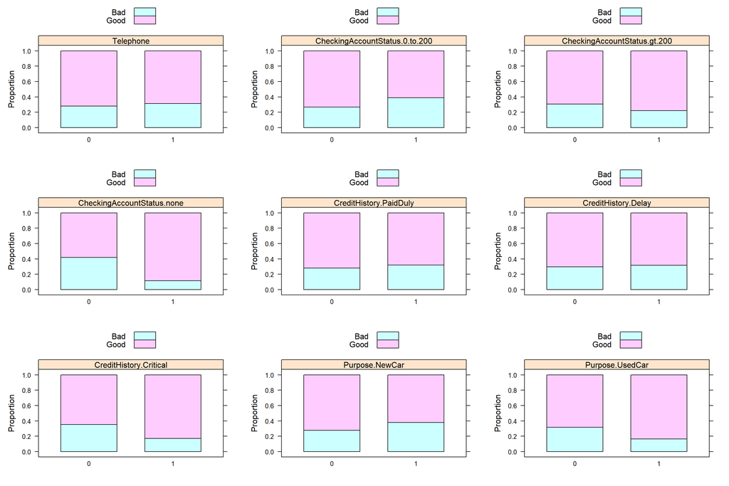

```r
PropTable_BarChart_33 <- barchart(Freq ~ Category | Variable,
         data=PropTable_Summary,
         groups = Class,
         stack=TRUE,
         ylab = "Proportion",
         auto.key = list(adj = 1))

Prop_Label <- names(EDA.Predictors.Factor)[34]
PropTable_Label <- paste0(Prop_Label,"_PropTable")
PropTable_Data <- EDA[,c("Class",Prop_Label)]
PropTable_Summary <- (assign(PropTable_Label,as.data.frame(prop.table(table(PropTable_Data), 2))))
PropTable_Summary$Variable <- rep(Prop_Label,nrow(PropTable_Summary))
PropTable_Summary$Category <- PropTable_Summary[,2]

PropTable_BarChart_34 <- barchart(Freq ~ Category | Variable,
         data=PropTable_Summary,
         groups = Class,
         stack=TRUE,
         ylab = "Proportion",
         auto.key = list(adj = 1))

Prop_Label <- names(EDA.Predictors.Factor)[35]
PropTable_Label <- paste0(Prop_Label,"_PropTable")
PropTable_Data <- EDA[,c("Class",Prop_Label)]
PropTable_Summary <- (assign(PropTable_Label,as.data.frame(prop.table(table(PropTable_Data), 2))))
PropTable_Summary$Variable <- rep(Prop_Label,nrow(PropTable_Summary))
PropTable_Summary$Category <- PropTable_Summary[,2]

PropTable_BarChart_35 <- barchart(Freq ~ Category | Variable,
         data=PropTable_Summary,
         groups = Class,
         stack=TRUE,
         ylab = "Proportion",
         auto.key = list(adj = 1))

Prop_Label <- names(EDA.Predictors.Factor)[36]
PropTable_Label <- paste0(Prop_Label,"_PropTable")
PropTable_Data <- EDA[,c("Class",Prop_Label)]
PropTable_Summary <- (assign(PropTable_Label,as.data.frame(prop.table(table(PropTable_Data), 2))))
PropTable_Summary$Variable <- rep(Prop_Label,nrow(PropTable_Summary))
PropTable_Summary$Category <- PropTable_Summary[,2]

PropTable_BarChart_36 <- barchart(Freq ~ Category | Variable,
         data=PropTable_Summary,
         groups = Class,
         stack=TRUE,
         ylab = "Proportion",
         auto.key = list(adj = 1))

grid.arrange(PropTable_BarChart_1,
             PropTable_BarChart_2,
             PropTable_BarChart_3,
             PropTable_BarChart_4,
             PropTable_BarChart_5,
             PropTable_BarChart_6,
             PropTable_BarChart_7,
             PropTable_BarChart_8,
             PropTable_BarChart_9,
             ncol = 3)
```

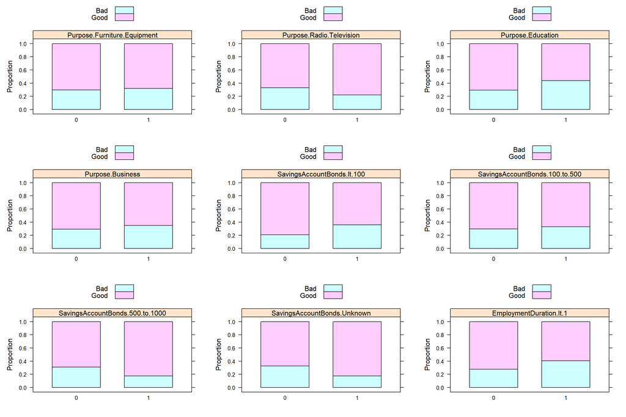

```r
grid.arrange(PropTable_BarChart_10,
             PropTable_BarChart_11,
             PropTable_BarChart_12,
             PropTable_BarChart_13,
             PropTable_BarChart_14,
             PropTable_BarChart_15,
             PropTable_BarChart_16,
             PropTable_BarChart_17,
             PropTable_BarChart_18,
             ncol = 3)
```

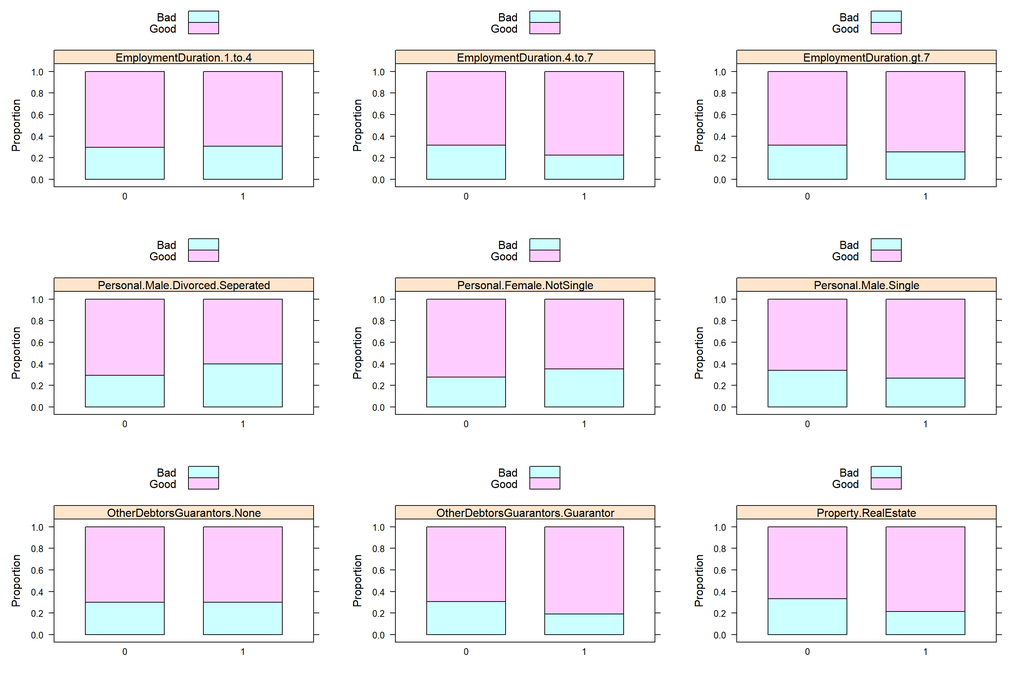

```r
grid.arrange(PropTable_BarChart_19,
             PropTable_BarChart_20,
             PropTable_BarChart_21,
             PropTable_BarChart_22,
             PropTable_BarChart_23,
             PropTable_BarChart_24,
             PropTable_BarChart_25,
             PropTable_BarChart_26,
             PropTable_BarChart_27,
             ncol = 3)
```

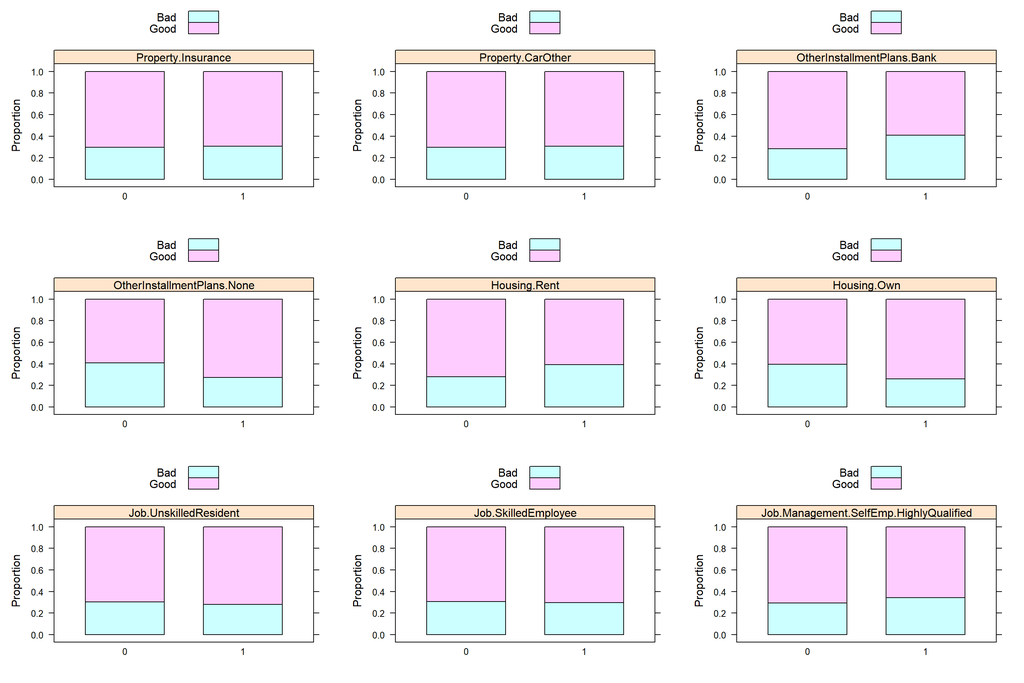

```r
grid.arrange(PropTable_BarChart_28,
             PropTable_BarChart_29,
             PropTable_BarChart_30,
             PropTable_BarChart_31,
             PropTable_BarChart_32,
             PropTable_BarChart_33,
             PropTable_BarChart_34,
             PropTable_BarChart_35,
             PropTable_BarChart_36,
             ncol = 3)
```